# Arvato Project Workbook

## Create a Customer Segmentation Report for Arvato Financial Services

The task of the project is to analyze demographics data for customers of a German mail-order sales company, comparing the data against demographic information for the general population in Germany. The unsupervised learning techniques to perform customer segmentation will be applied, and the the main features of the core customer group will be described. A data sheet with demographics information for targets of a marketing campaign for the company is also referred; also a supervising model to predict whether individuals are most likely to convert into becoming customers for the company will be utilized.

In this Jupyternote book, the procedure is basically spereated into few parts listed below:

- Know the data: get to understand the dataset and explore which sections of the datasets need to be wrangled.
- Data Wrangling: Based on the findings above, apply a function to clean the data, and explain reasons to cope with the features that are uncenessary.
- Customer Segmentation Report: the method of K-modes is used as an unsupervised learning technnique in the project, and the reason of using this techique is also mentioned. According to the result of clustering, 5 clusters could be formed, and the critical features of the interested cluster are presented.
- Supervised Learning Model: The true meaning behind the quantitavie values of numerous features is actually representation of each categories. In other words, the major task of this project is to cope with complex features of classification. As a result, sevearl classification algorithms are utilized, and metrics of evaluation is also introduced. Finally, the result of prediction is conveyed.
- Conclusion: summarize the findings, challenge, and the limitation of my work.

```python
# Import necessary packages
import re
import pandas as pd
import numpy as np
import matplotlib.pyplot as plt
import seaborn as sb
from sklearn.impute import SimpleImputer
from sklearn.pipeline import Pipeline
from sklearn.compose import ColumnTransformer
from sklearn.preprocessing import StandardScaler, FunctionTransformer
from kmodes.kmodes import KModes
from sklearn.utils import resample

import time
from sklearn.metrics import accuracy_score, roc_auc_score
from sklearn.model_selection import train_test_split, GridSearchCV
from sklearn.linear_model import LogisticRegression
from sklearn.tree import DecisionTreeClassifier
from sklearn.ensemble import RandomForestClassifier, AdaBoostClassifier, GradientBoostingClassifier
from sklearn.metrics import roc_auc_score, roc_curve, precision_recall_curve, auc,accuracy_score,confusion_matrix,classification_report



# Better display for Jupyter notebooks
import warnings
%matplotlib inline
%config InlineBachend.figure_format = 'retina'
warnings.simplefilter("ignore")
```

```python
def list_null_percentage (df):

    '''
    Description: present null percentage of each column

    Input:
    df : (type:dataframe) the dataframe that would like to present the percentage of null columns

    Output:
    list_null_percenrage: A list of columns with null percentage
    '''
    null_percentage_df = ((df.isnull().sum() / df.shape[0]*100).round(2))
    null_percentage = null_percentage_df.sort_values(ascending=False).to_string()

    return print (null_percentage)
```

```python
def plot_null_percentage (df, m):

    '''
    Description: present null percentage of each column

    Input:
    df : (type:dataframe) the dataframe that would like to present the percentage of null columns
    m : (type: int) number of features with missing values are visualized

    Output:
    list_null_percenrage: A list of columns with null percentage
    '''
    base_color = sb.color_palette()[0]
    null_percentage_df = (df.isnull().sum() / df.shape[0]*100).round(2)
    plot_null_percentage = null_percentage_df.sort_values(ascending=False)[:m].plot(kind='bar',
                                                                                     figsize=(20,8),
                                                                                     fontsize=13,
                                                                                     color = base_color)

    plt.title("Percentage , \nDistribution of null values in the dataset",fontsize=13,fontweight="bold")
    plt.xlabel("Variables",fontsize=13)
    plt.ylabel("Proportion",fontsize=13)

    return plot_null_percentage
```

```python
# lp & wohn is short for LP_* & WOHNLAGE*

def encode_lp_wohn(df):
    """
    Re-encode LP_* & WOHNLAGE columns:

    Input:
    df : (type:dataframe) the dataframe to be transformed

    - replace 0s with nan values
    - drop complex and/or duplicate columns
    - split columns with mixed features.

    Output:
    df : feature transformed dataframe
    """
    # replace 0s with nan values
    cols = ["LP_LEBENSPHASE_FEIN","LP_LEBENSPHASE_GROB", "LP_FAMILIE_FEIN", "LP_FAMILIE_GROB","WOHNLAGE"]
    df[cols] = df[cols].replace({0: np
                                 .nan})

    # drop complex and/or duplicate columns
    df.drop(['LP_FAMILIE_FEIN','LP_STATUS_FEIN','LP_LEBENSPHASE_FEIN','LP_LEBENSPHASE_GROB'], axis=1, inplace=True)

    # re-encode LP_STATUS_GROB and LP_FAMILIE_GROB
    status = {1: 1, 2: 1, 3: 2,
              4: 2, 5: 2, 6: 3,
              7: 3, 8: 4, 9: 4,
              10: 5}
    family = {1: 1, 2: 2, 3: 3,
               4: 3, 5: 3, 6: 4,
               7: 4, 8: 4, 9: 5,
               10: 5, 11: 5}

    wohn = {1: 1, 2: 1, 3: 2,
            4: 3, 5: 3, 6: 4,
            7: 4, 8: 4 }

    df["LP_STATUS_GROB"] = df["LP_STATUS_GROB"].map(status)
    df["LP_FAMILIE_GROB"] = df["LP_FAMILIE_GROB"].map(family)
    df["WOHNLAGE"] = df["WOHNLAGE"].map(wohn)

    return df
```

```python
# pj is short for PRAEGENDE_JUGENDJAHRE
def encode_pj(i):
    """
    Re-encode PRAEGENDE_JUGENDJAHRE as a binary feature:

    0: Mainstream
    1: Avantgarde
    """
    mainstream = [1, 3, 5, 8, 10, 12, 14]
    avantgarde = [2, 4, 6, 7, 9, 11, 13, 15]
    if i in mainstream:
        return 0
    elif i in avantgarde:
        return 1
    else:
        return i
```

```python
# Function to fit the method
def model_training(model, X_train, y_train, X_test, y_test):
    '''
    Th function is to customizeof the fit method

    Input:
    model: The model from the list of the classifiers/models
    X_train - The training data
    y_train - The training feature
    X_test - The validation of data
    y_test - The validation of feature

    Output:
    ROC-AUC score
    Training time
    '''
    t = time.time()
    model = model.fit(X_train, y_train)
    y_pred = model.predict_proba(X_test)[:,1]

    roc_score = roc_auc_score(y_test, y_pred)

    train_time = time.time() - t

    return roc_score, train_time
```

```python
# Function to iterate over classifier and fir method
def test_model(training_models, X_train, y_train, X_test, y_test):
    '''
    This function iterates over declared classifiers and calls the custom fit method.

    Input:
    classifiers - The list of the classifiers/models
    X_train - The training data
    y_train - The training features
    X_test - The validation data
    y_test - The validation features

    Output:
    df: (dataframe) The resulting dataframe for comparison
    '''
    result={
    'Training Model':[],
    'ROC Score':[],
    'Training Time':[]
    }

    for name, clf in training_models:
        score, t = model_training(clf, X_train, y_train, X_test, y_test)
        result['Training Model'].append(name)
        result['ROC Score'].append(score)
        result['Training Time'].append(t)

    results_df = pd.DataFrame.from_dict(result, orient='index').transpose()

    return results_df
```

```python
def evaluate_model_ROC(best_clf, X_test, y_test):
    """Draw ROC curve for the model
    Input:
        Classification Model
        X_test, y_test, Array-like(model_classifer_obj)
    Output:
        ROC curve
    """
    y_pred = best_clf.predict_proba(X_test)[:,1]
    fpr, tpr, th = roc_curve(y_test, y_pred)
    roc_auc = auc(fpr, tpr) # compute area under the curve
    plt.figure()
    plt.plot(fpr, tpr, label='ROC curve (area = %0.2f)' % (roc_auc))
    plt.plot([0, 1], [0, 1], 'k--')
    plt.xlim([0.0, 1.0])
    plt.ylim([0.0, 1.05])
    plt.xlabel('False Positive Rate')
    plt.ylabel('True Positive Rate')
    plt.title('Receiver Operating Characteristic Curve')
    plt.legend(loc="lower right")
```

## Get to Know the Data

### Dimension of datasets

```python
# Load the data

# df1 == 'Udacity_AZDIAS_052018.csv'
df1 = pd.read_csv('/Users/johnma/Desktop/Udacity_Data Scientist/Project folder/Project 4_Capstone Project/data/Udacity_AZDIAS_052018.csv', sep=';')

# df2 == 'Udacity_CUSTOMERS_052018.csv'
df2 = pd.read_csv('/Users/johnma/Desktop/Udacity_Data Scientist/Project folder/Project 4_Capstone Project/data/Udacity_CUSTOMERS_052018.csv', sep=';')

# Display all the columns of dataset
pd.set_option('display.max_columns', None)

# Display all the rows of dataset
pd.set_option('display.max_rows', None)
```

```python
# Make a copy of original dataset
df1 = df1.copy()
df2 = df2.copy()
```

```python
# Data shape: origin dataframe of Azdias

print('Origin Data shape of Azdias (rows, cols): ', df1.shape)
print ('--'*30)
df1.head()
```

```
Origin Data shape of Azdias (rows, cols):  (891221, 366)
------------------------------------------------------------
```

|  | LNR | AGER_TYP | AKT_DAT_KL | ALTER_HH | ALTER_KIND1 | ALTER_KIND2 | ALTER_KIND3 | ALTER_KIND4 | ALTERSKATEGORIE_FEIN | ANZ_HAUSHALTE_AKTIV | ANZ_HH_TITEL | ANZ_KINDER | ANZ_PERSONEN | ANZ_STATISTISCHE_HAUSHALTE | ANZ_TITEL | ARBEIT | BALLRAUM | CAMEO_DEU_2015 | CAMEO_DEUG_2015 | CAMEO_INTL_2015 | CJT_GESAMTTYP | CJT_KATALOGNUTZER | CJT_TYP_1 | CJT_TYP_2 | CJT_TYP_3 | CJT_TYP_4 | CJT_TYP_5 | CJT_TYP_6 | D19_BANKEN_ANZ_12 | … |
| --- | --- | --- | --- | --- | --- | --- | --- | --- | --- | --- | --- | --- | --- | --- | --- | --- | --- | --- | --- | --- | --- | --- | --- | --- | --- | --- | --- | --- | --- | --- |
| 0 | 910215 | -1 | NaN | NaN | NaN | NaN | NaN | NaN | NaN | NaN | NaN | NaN | NaN | NaN | NaN | NaN | NaN | NaN | NaN | NaN | 2.0 | 5.0 | 1.0 | 1.0 | 5.0 | 5.0 | 5.0 | 5.0 | 0 | … |
| 1 | 910220 | -1 | 9.0 | 0.0 | NaN | NaN | NaN | NaN | 21.0 | 11.0 | 0.0 | 0.0 | 2.0 | 12.0 | 0.0 | 3.0 | 6.0 | 8A | 8.0 | 51.0 | 5.0 | 1.0 | 5.0 | 5.0 | 2.0 | 3.0 | 1.0 | 1.0 | 0 | … |
| 2 | 910225 | -1 | 9.0 | 17.0 | NaN | NaN | NaN | NaN | 17.0 | 10.0 | 0.0 | 0.0 | 1.0 | 7.0 | 0.0 | 3.0 | 2.0 | 4C | 4.0 | 24.0 | 3.0 | 2.0 | 4.0 | 4.0 | 1.0 | 3.0 | 2.0 | 2.0 | 0 | … |
| 3 | 910226 | 2 | 1.0 | 13.0 | NaN | NaN | NaN | NaN | 13.0 | 1.0 | 0.0 | 0.0 | 0.0 | 2.0 | 0.0 | 2.0 | 4.0 | 2A | 2.0 | 12.0 | 2.0 | 3.0 | 2.0 | 2.0 | 4.0 | 4.0 | 5.0 | 3.0 | 0 | … |
| 4 | 910241 | -1 | 1.0 | 20.0 | NaN | NaN | NaN | NaN | 14.0 | 3.0 | 0.0 | 0.0 | 4.0 | 3.0 | 0.0 | 4.0 | 2.0 | 6B | 6.0 | 43.0 | 5.0 | 3.0 | 3.0 | 3.0 | 3.0 | 4.0 | 3.0 | 3.0 | 3 | … |

```python
# Data shape of Customer

print('Data shape of Customers (rows, cols): ', df2.shape)
print ('--'*30)
df2.head()
```

```
Data shape of Customers (rows, cols):  (191652, 369)
------------------------------------------------------------
```

|  | LNR | AGER_TYP | AKT_DAT_KL | ALTER_HH | ALTER_KIND1 | ALTER_KIND2 | ALTER_KIND3 | ALTER_KIND4 | ALTERSKATEGORIE_FEIN | ANZ_HAUSHALTE_AKTIV | ANZ_HH_TITEL | ANZ_KINDER | ANZ_PERSONEN | ANZ_STATISTISCHE_HAUSHALTE | ANZ_TITEL | ARBEIT | BALLRAUM | CAMEO_DEU_2015 | CAMEO_DEUG_2015 | CAMEO_INTL_2015 | CJT_GESAMTTYP | CJT_KATALOGNUTZER | CJT_TYP_1 | CJT_TYP_2 | CJT_TYP_3 | CJT_TYP_4 | CJT_TYP_5 | CJT_TYP_6 | D19_BANKEN_ANZ_12 | … |
| --- | --- | --- | --- | --- | --- | --- | --- | --- | --- | --- | --- | --- | --- | --- | --- | --- | --- | --- | --- | --- | --- | --- | --- | --- | --- | --- | --- | --- | --- | --- |
| 0 | 9626 | 2 | 1.0 | 10.0 | NaN | NaN | NaN | NaN | 10.0 | 1.0 | 0.0 | 0.0 | 2.0 | 1.0 | 0.0 | 1.0 | 3.0 | 1A | 1.0 | 13.0 | 5.0 | 4.0 | 1.0 | 1.0 | 5.0 | 5.0 | 5.0 | 5.0 | 0 | … |
| 1 | 9628 | -1 | 9.0 | 11.0 | NaN | NaN | NaN | NaN | NaN | NaN | NaN | 0.0 | 3.0 | NaN | 0.0 | NaN | NaN | NaN | NaN | NaN | NaN | NaN | NaN | NaN | NaN | NaN | NaN | NaN | 0 | … |
| 2 | 143872 | -1 | 1.0 | 6.0 | NaN | NaN | NaN | NaN | 0.0 | 1.0 | 0.0 | 0.0 | 1.0 | 1.0 | 0.0 | 3.0 | 7.0 | 5D | 5.0 | 34.0 | 2.0 | 5.0 | 2.0 | 2.0 | 5.0 | 5.0 | 5.0 | 5.0 | 0 | … |
| 3 | 143873 | 1 | 1.0 | 8.0 | NaN | NaN | NaN | NaN | 8.0 | 0.0 | NaN | 0.0 | 0.0 | 1.0 | 0.0 | 1.0 | 7.0 | 4C | 4.0 | 24.0 | 2.0 | 5.0 | 1.0 | 1.0 | 5.0 | 5.0 | 5.0 | 5.0 | 0 | … |
| 4 | 143874 | -1 | 1.0 | 20.0 | NaN | NaN | NaN | NaN | 14.0 | 7.0 | 0.0 | 0.0 | 4.0 | 7.0 | 0.0 | 3.0 | 3.0 | 7B | 7.0 | 41.0 | 6.0 | 4.0 | 3.0 | 3.0 | 3.0 | 4.0 | 3.0 | 3.0 | 1 | … |

```python
# Differences in columns

diff_features = set(df2.columns) - set(df1.columns)
print ('The exclusive features in Customers are ',diff_features)
```

```
The exclusive features in Customers are  {'ONLINE_PURCHASE', 'PRODUCT_GROUP', 'CUSTOMER_GROUP'}
```

```python
print ('Show data info of Azdias')
print ('==============================')
print (df1.info())
print ('==============================')
print ('Show data info of Customers')
print ('==============================')
print (df2.info())
```

```
Show data info of Azdias
==============================
<class 'pandas.core.frame.DataFrame'>
RangeIndex: 891221 entries, 0 to 891220
Columns: 366 entries, LNR to ALTERSKATEGORIE_GROB
dtypes: float64(267), int64(93), object(6)
memory usage: 2.4+ GB
None
==============================
Show data info of Customers
==============================
<class 'pandas.core.frame.DataFrame'>
RangeIndex: 191652 entries, 0 to 191651
Columns: 369 entries, LNR to ALTERSKATEGORIE_GROB
dtypes: float64(267), int64(94), object(8)
memory usage: 539.5+ MB
None
```

### Further exploration of unknown value

In order to avoid values without meaning, we should find out values that map the "Meaning" in the sheet of "DIAS Attributes - Values 2017.csv" belonging to "unknown" or "unknown / no main age detectable". Such values should be treated as "Nan" since we do not know what does it mean.

```python
# Load document of feature explaination
attributes_values = pd.read_csv('/Users/johnma/Desktop/Udacity_Data Scientist/Project folder/Project 4_Capstone Project/DIAS Attributes - Values 2017.csv')
attributes_values = attributes_values[attributes_values['Attribute'].notnull()]

print('attributes_values|Data shape (rows, cols): ', attributes_values.shape)
print()
attributes_values.head()
```

```
attributes_values|Data shape (rows, cols):  (314, 4)
```

|  | Attribute | Description | Value | Meaning |
| --- | --- | --- | --- | --- |
| 0 | AGER_TYP | best-ager typology | -1 | unknown |
| 5 | ALTERSKATEGORIE_GROB | age classification through prename analysis | -1, 0 | unknown |
| 11 | ALTER_HH | main age within the household | 0 | unknown / no main age detectable |
| 33 | ANREDE_KZ | gender | -1, 0 | unknown |
| 36 | ANZ_HAUSHALTE_AKTIV | number of households in the building | … | numeric value (typically coded from 1-10) |

```python
# check content of meaning for each attribute
attributes_values['Meaning'].unique().tolist()
```

```
['unknown',
 'unknown / no main age detectable',
 'numeric value (typically coded from 1-10)',
 'numeric value (typically coded from 1-3)',
 'Work-Life-Balance',
 'no transactions known',
 'highest activity within the last 12 months',
 'no transaction known',
 'no Online-transactions within the last 12 months',
 'Universal',
 'business cell',
 'numeric value',
 'Event travelers',
 "doesn't belong to the green avantgarde",
 'very low car quote',
 'building is located in a 125 x 125m-grid cell (RA1), which is a consumption cell',
 'single ',
 'single low-income earners of younger age',
 'single low-income- and average earners of younger age ',
 'typical low-income earners',
 'low-income earners',
 'very high mobility',
 'none',
 'mainly 1-2 family homes',
 'very low']
```

```python
# Get attributes value with 'unknown', 'unknown / no main age detectable' as unkown

unknown = attributes_values[attributes_values['Meaning'].isin(['unknown', 'unknown / no main age detectable'])]
print (set(unknown['Meaning'].tolist()))
print()
unknown.head()
```

```
{'unknown', 'unknown / no main age detectable'}
```

|  | Attribute | Description | Value | Meaning |
| --- | --- | --- | --- | --- |
| 0 | AGER_TYP | best-ager typology | -1 | unknown |
| 5 | ALTERSKATEGORIE_GROB | age classification through prename analysis | -1, 0 | unknown |
| 11 | ALTER_HH | main age within the household | 0 | unknown / no main age detectable |
| 33 | ANREDE_KZ | gender | -1, 0 | unknown |
| 40 | BALLRAUM | distance to next urban centre | -1 | unknown |

```python
# Convert values of both datasets (df1&df2) equal to unkown attributes into NaN

for df in [df1, df2]:
    for column in df.columns:
        if df[column].dtype == np.int64:
            df[column] = df[column].astype(np.float64)
        if column not in set(unknown['Attribute']):
            continue

        unknown_value = unknown.loc[unknown['Attribute'] == column].Value.item()
        unknown_value = set(float(x) for x in unknown_value.split(', ')) if type(unknown_value) is str else set([float(unknown_value)])
        df[column] = df[column].mask(df[column].isin(unknown_value), other=np.nan)
```

```python
print('AZDIAS|Data shape (rows, cols): ', df1.shape)
print()
df1.head()
```

```
AZDIAS|Data shape (rows, cols):  (891221, 366)
```

|  | LNR | AGER_TYP | AKT_DAT_KL | ALTER_HH | ALTER_KIND1 | ALTER_KIND2 | ALTER_KIND3 | ALTER_KIND4 | ALTERSKATEGORIE_FEIN | ANZ_HAUSHALTE_AKTIV | ANZ_HH_TITEL | ANZ_KINDER | ANZ_PERSONEN | ANZ_STATISTISCHE_HAUSHALTE | ANZ_TITEL | ARBEIT | BALLRAUM | CAMEO_DEU_2015 | CAMEO_DEUG_2015 | CAMEO_INTL_2015 | CJT_GESAMTTYP | CJT_KATALOGNUTZER | CJT_TYP_1 | CJT_TYP_2 | CJT_TYP_3 | CJT_TYP_4 | CJT_TYP_5 | CJT_TYP_6 | D19_BANKEN_ANZ_12 | … |
| --- | --- | --- | --- | --- | --- | --- | --- | --- | --- | --- | --- | --- | --- | --- | --- | --- | --- | --- | --- | --- | --- | --- | --- | --- | --- | --- | --- | --- | --- | --- |
| 0 | 910215.0 | NaN | NaN | NaN | NaN | NaN | NaN | NaN | NaN | NaN | NaN | NaN | NaN | NaN | NaN | NaN | NaN | NaN | NaN | NaN | 2.0 | 5.0 | 1.0 | 1.0 | 5.0 | 5.0 | 5.0 | 5.0 | 0.0 | … |
| 1 | 910220.0 | NaN | 9.0 | NaN | NaN | NaN | NaN | NaN | 21.0 | 11.0 | 0.0 | 0.0 | 2.0 | 12.0 | 0.0 | 3.0 | 6.0 | 8A | 8.0 | 51.0 | 5.0 | 1.0 | 5.0 | 5.0 | 2.0 | 3.0 | 1.0 | 1.0 | 0.0 | … |
| 2 | 910225.0 | NaN | 9.0 | 17.0 | NaN | NaN | NaN | NaN | 17.0 | 10.0 | 0.0 | 0.0 | 1.0 | 7.0 | 0.0 | 3.0 | 2.0 | 4C | 4.0 | 24.0 | 3.0 | 2.0 | 4.0 | 4.0 | 1.0 | 3.0 | 2.0 | 2.0 | 0.0 | … |
| 3 | 910226.0 | 2.0 | 1.0 | 13.0 | NaN | NaN | NaN | NaN | 13.0 | 1.0 | 0.0 | 0.0 | 0.0 | 2.0 | 0.0 | 2.0 | 4.0 | 2A | 2.0 | 12.0 | 2.0 | 3.0 | 2.0 | 2.0 | 4.0 | 4.0 | 5.0 | 3.0 | 0.0 | … |
| 4 | 910241.0 | NaN | 1.0 | 20.0 | NaN | NaN | NaN | NaN | 14.0 | 3.0 | 0.0 | 0.0 | 4.0 | 3.0 | 0.0 | 4.0 | 2.0 | 6B | 6.0 | 43.0 | 5.0 | 3.0 | 3.0 | 3.0 | 3.0 | 4.0 | 3.0 | 3.0 | 3.0 | … |

```python
print('CUSTOMER|Data shape (rows, cols): ', df2.shape)
print()
df2.head()
```

```
CUSTOMER|Data shape (rows, cols):  (191652, 369)
```

|  | LNR | AGER_TYP | AKT_DAT_KL | ALTER_HH | ALTER_KIND1 | ALTER_KIND2 | ALTER_KIND3 | ALTER_KIND4 | ALTERSKATEGORIE_FEIN | ANZ_HAUSHALTE_AKTIV | ANZ_HH_TITEL | ANZ_KINDER | ANZ_PERSONEN | ANZ_STATISTISCHE_HAUSHALTE | ANZ_TITEL | ARBEIT | BALLRAUM | CAMEO_DEU_2015 | CAMEO_DEUG_2015 | CAMEO_INTL_2015 | CJT_GESAMTTYP | CJT_KATALOGNUTZER | CJT_TYP_1 | CJT_TYP_2 | CJT_TYP_3 | CJT_TYP_4 | CJT_TYP_5 | CJT_TYP_6 | D19_BANKEN_ANZ_12 | … |
| --- | --- | --- | --- | --- | --- | --- | --- | --- | --- | --- | --- | --- | --- | --- | --- | --- | --- | --- | --- | --- | --- | --- | --- | --- | --- | --- | --- | --- | --- | --- |
| 0 | 9626.0 | 2.0 | 1.0 | 10.0 | NaN | NaN | NaN | NaN | 10.0 | 1.0 | 0.0 | 0.0 | 2.0 | 1.0 | 0.0 | 1.0 | 3.0 | 1A | 1.0 | 13.0 | 5.0 | 4.0 | 1.0 | 1.0 | 5.0 | 5.0 | 5.0 | 5.0 | 0.0 | … |
| 1 | 9628.0 | NaN | 9.0 | 11.0 | NaN | NaN | NaN | NaN | NaN | NaN | NaN | 0.0 | 3.0 | NaN | 0.0 | NaN | NaN | NaN | NaN | NaN | NaN | NaN | NaN | NaN | NaN | NaN | NaN | NaN | 0.0 | … |
| 2 | 143872.0 | NaN | 1.0 | 6.0 | NaN | NaN | NaN | NaN | 0.0 | 1.0 | 0.0 | 0.0 | 1.0 | 1.0 | 0.0 | 3.0 | 7.0 | 5D | 5.0 | 34.0 | 2.0 | 5.0 | 2.0 | 2.0 | 5.0 | 5.0 | 5.0 | 5.0 | 0.0 | … |
| 3 | 143873.0 | 1.0 | 1.0 | 8.0 | NaN | NaN | NaN | NaN | 8.0 | 0.0 | NaN | 0.0 | 0.0 | 1.0 | 0.0 | 1.0 | 7.0 | 4C | 4.0 | 24.0 | 2.0 | 5.0 | 1.0 | 1.0 | 5.0 | 5.0 | 5.0 | 5.0 | 0.0 | … |
| 4 | 143874.0 | NaN | 1.0 | 20.0 | NaN | NaN | NaN | NaN | 14.0 | 7.0 | 0.0 | 0.0 | 4.0 | 7.0 | 0.0 | 3.0 | 3.0 | 7B | 7.0 | 41.0 | 6.0 | 4.0 | 3.0 | 3.0 | 3.0 | 4.0 | 3.0 | 3.0 | 1.0 | … |

### Investigation of features need to be wranggled

**a. object features**

```python
#df1.select_dtypes(['object']).head(6)
```

```python
#df2.select_dtypes(['object']).head(8)
```

```python
# find out columns with the type as object
df1_object_cols = df1.columns[df1.dtypes == "object"]

for col in df1_object_cols:
    print(col, ': ', len(df1[col].unique()), 'unique values, ', df1[col].unique())
```

```
CAMEO_DEU_2015 :  46 unique values,  [nan '8A' '4C' '2A' '6B' '8C' '4A' '2D' '1A' '1E' '9D' '5C' '8B' '7A' '5D'
 '9E' '9B' '1B' '3D' '4E' '4B' '3C' '5A' '7B' '9A' '6D' '6E' '2C' '7C'
 '9C' '7D' '5E' '1D' '8D' '6C' '6A' '5B' '4D' '3A' '2B' '7E' '3B' '6F'
 '5F' '1C' 'XX']
CAMEO_DEUG_2015 :  20 unique values,  [nan 8.0 4.0 2.0 6.0 1.0 9.0 5.0 7.0 3.0 '4' '3' '7' '2' '8' '9' '6' '5'
 '1' 'X']
CAMEO_INTL_2015 :  44 unique values,  [nan 51.0 24.0 12.0 43.0 54.0 22.0 14.0 13.0 15.0 33.0 41.0 34.0 55.0 25.0
 23.0 31.0 52.0 35.0 45.0 44.0 32.0 '22' '24' '41' '12' '54' '51' '44'
 '35' '23' '25' '14' '34' '52' '55' '31' '32' '15' '13' '43' '33' '45'
 'XX']
D19_LETZTER_KAUF_BRANCHE :  36 unique values,  [nan 'D19_UNBEKANNT' 'D19_SCHUHE' 'D19_ENERGIE' 'D19_KOSMETIK'
 'D19_VOLLSORTIMENT' 'D19_SONSTIGE' 'D19_BANKEN_GROSS'
 'D19_DROGERIEARTIKEL' 'D19_HANDWERK' 'D19_BUCH_CD' 'D19_VERSICHERUNGEN'
 'D19_VERSAND_REST' 'D19_TELKO_REST' 'D19_BANKEN_DIREKT' 'D19_BANKEN_REST'
 'D19_FREIZEIT' 'D19_LEBENSMITTEL' 'D19_HAUS_DEKO' 'D19_BEKLEIDUNG_REST'
 'D19_SAMMELARTIKEL' 'D19_TELKO_MOBILE' 'D19_REISEN' 'D19_BEKLEIDUNG_GEH'
 'D19_TECHNIK' 'D19_NAHRUNGSERGAENZUNG' 'D19_DIGIT_SERV' 'D19_LOTTO'
 'D19_RATGEBER' 'D19_TIERARTIKEL' 'D19_KINDERARTIKEL' 'D19_BIO_OEKO'
 'D19_WEIN_FEINKOST' 'D19_GARTEN' 'D19_BILDUNG' 'D19_BANKEN_LOKAL']
EINGEFUEGT_AM :  5163 unique values,  [nan '1992-02-10 00:00:00' '1992-02-12 00:00:00' ... '2010-12-02 00:00:00'
 '2005-03-19 00:00:00' '2011-11-18 00:00:00']
OST_WEST_KZ :  3 unique values,  [nan 'W' 'O']
```

> - Compared to Azidas, dataset of Customers have three extra categorical variables, that are 'ONLINE_PURCHASE', 'CUSTOMER_GROUP', and 'PRODUCT_GROUP'.
> - 'CAMEO_DEUG_2015' & 'CAMEO_INTL_2015':
>   > - Convert "X" or "XX" as "Nan"
> - 'CAMEO_INTL_2015' can be split into two seperated features:

> > **'CAMEO_INTL_2015_WEALTH' (Based on the first value of the origian value):**

> > ```
> > * 1. Wealthy <br>
> > * 2. Prosperous <br>
> > * 3. Comfortable <br>
> > * 4. Less Affluent <br>
> > * 5. Poor <br>
> > ```

> > **"CAMEO_INTL_2015_STATUS" (Based on the 2nd value of the origin value):**

> > ```
> > * 1. Pre-Family Couples & Singles<br>
> > * 2. Young Couples With Children<br>
> > * 3. Families With School Age Children<br>
> > * 4. Older Families &  Mature Couples<br>
> > * 5. Elders In Retirement
> > ```

> - For feature 'OST_WEST_KZ':
>   > - Converted to 0/1 with 0 = OST and 1 = WEST
> - 'CAMEO_DEU_2015' and'D19_LETZTER_KAUF_BRANCHE',''EINGEFUEGT_AM' have too many unique values, and plan to drop them.
> - 'LNR' looks like an unique identifier --> will drop.

**b. Convert mixed features to numerical vlaues**

```python
print('LP_LEBENSPHASE_FEIN: ', len(df1["LP_LEBENSPHASE_FEIN"].unique()), \
      'values, ', df1["LP_LEBENSPHASE_FEIN"].unique())

print('LP_LEBENSPHASE_GROB: ', len(df1["LP_LEBENSPHASE_GROB"].unique()), \
      'values, ', df1["LP_LEBENSPHASE_GROB"].unique())

print('LP_STATUS_FEIN: ', len(df1["LP_STATUS_FEIN"].unique()), \
      'values, ', df1["LP_STATUS_FEIN"].unique())

print('LP_STATUS_GROB: ', len(df1["LP_STATUS_GROB"].unique()), \
      'values, ', df1["LP_STATUS_GROB"].unique())

print('LP_FAMILIE_FEIN: ', len(df1["LP_FAMILIE_FEIN"].unique()), \
      'values, ', df1["LP_FAMILIE_FEIN"].unique())

print('LP_FAMILIE_GROB: ', len(df1["LP_FAMILIE_GROB"].unique()), \
      'values, ', df1["LP_FAMILIE_GROB"].unique())

print('PRAEGENDE_JUGENDJAHRE: ', len(df1["PRAEGENDE_JUGENDJAHRE"].unique()), \
      'values, ', df1["PRAEGENDE_JUGENDJAHRE"].unique())

print('WOHNLAGE: ', len(df1["WOHNLAGE"].unique()), \
      'values, ', df1["WOHNLAGE"].unique())
```

```
LP_LEBENSPHASE_FEIN:  42 values,  [15. 21.  3.  0. 32.  8.  2.  5. 10.  4.  6. 23. 12. 20.  1. 11. 25. 13.
  7. 18. 31. 19. 38. 35. 30. 22. 14. 33. 29. 24. 28. 37. 26. 39. 27. 36.
  9. 34. nan 40. 16. 17.]
LP_LEBENSPHASE_GROB:  14 values,  [ 4.  6.  1.  0. 10.  2.  3.  5.  7. 12. 11.  9.  8. nan]
LP_STATUS_FEIN:  11 values,  [ 1.  2.  3.  9.  4. 10.  5.  8.  6.  7. nan]
LP_STATUS_GROB:  6 values,  [ 1.  2.  4.  5.  3. nan]
LP_FAMILIE_FEIN:  13 values,  [ 2.  5.  1.  0. 10.  7. 11.  3.  8.  4.  6. nan  9.]
LP_FAMILIE_GROB:  7 values,  [ 2.  3.  1.  0.  5.  4. nan]
PRAEGENDE_JUGENDJAHRE:  16 values,  [nan 14. 15.  8.  3. 10. 11.  5.  9.  6.  4.  2.  1. 12. 13.  7.]
WOHNLAGE:  9 values,  [nan  4.  2.  7.  3.  5.  1.  8.  0.]
```

> - "0" should be treated as NaN since it is not discribed in "DIAS ATTRIBUTES - Values 2017"
> - "LP_LEBENSPHASE_FEIN" and "LP_LEBENSPHASE_GROB" should be removed since they have complex unique features.
> - The discription in "DIAS ATTRIBUTES - Values 2017" reveals that feature names end with "FEIN" have detail information with those end with "GROB", and these pair features actualy address identical information. As a result, we should drop "LP_STATUS_FEIN" and "LP_FAMILIE_FEIN", and reserve "LP_STATUS_GROB" and "LP_FAMILIE_GROB"
> - "LP_STATUS_GROB" and "LP_FAMILIE_GROB" can be re-encoded as below:
>   > - **"LP_STATUS_GROB"**  
>   >   1: low-income  
>   >   2: average-income  
>   >   3: independant  
>   >   4: houseowner  
>   >   5: top earner
>   > - **LP_FAMILIE_GROB**  
>   >   1: single  
>   >   2: couple  
>   >   3: single parent  
>   >   4: family  
>   >   5: multi-person household
> - According to the "DIAS ATTRIBUTES - Values 2017", further feature engineering can be:
>   > - **"PRAEGENDE_JUGENDJAHRE"** can be encoded into binaray (mainstream & avantgarde) from numeric values ranging from 1 to 15
>   > - **"WOHNLAGE"**  
>   >   1: Good Neighbourhood  
>   >   2: Average  
>   >   3: Poor Neighbourhood  
>   >   4: Rural

### Explore the missing values

```python
#df1.describe()
```

```python
#df2.describe()
```

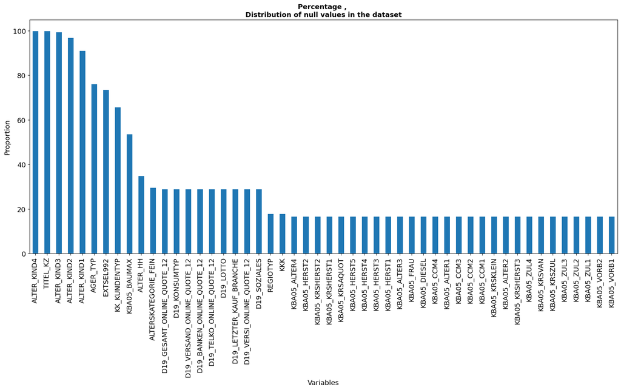

```python
# Plot top 50 columns with most missing values in Azdias
plot_null_percentage(df1, 50)
```

```python
## Check null in all columns by percentage in df1
list_null_percentage (df1)
```

```
ALTER_KIND4                    99.86
TITEL_KZ                       99.76
ALTER_KIND3                    99.31
ALTER_KIND2                    96.69
ALTER_KIND1                    90.90
AGER_TYP                       76.02
EXTSEL992                      73.40
KK_KUNDENTYP                   65.60
KBA05_BAUMAX                   53.47
ALTER_HH                       34.81
ALTERSKATEGORIE_FEIN           29.50
D19_GESAMT_ONLINE_QUOTE_12     28.85
D19_KONSUMTYP                  28.85
D19_VERSAND_ONLINE_QUOTE_12    28.85
D19_BANKEN_ONLINE_QUOTE_12     28.85
D19_TELKO_ONLINE_QUOTE_12      28.85
D19_LOTTO                      28.85
D19_LETZTER_KAUF_BRANCHE       28.85
D19_VERSI_ONLINE_QUOTE_12      28.85
D19_SOZIALES                   28.85
REGIOTYP                       17.74
KKK                            17.74
KBA05_ALTER4                   16.62
KBA05_HERST2                   16.62
KBA05_KRSHERST2                16.62
KBA05_KRSHERST1                16.62
KBA05_KRSAQUOT                 16.62
KBA05_HERST5                   16.62
KBA05_HERST4                   16.62
KBA05_HERST3                   16.62
KBA05_HERST1                   16.62
KBA05_ALTER3                   16.62
KBA05_FRAU                     16.62
KBA05_DIESEL                   16.62
KBA05_CCM4                     16.62
KBA05_ALTER1                   16.62
KBA05_CCM3                     16.62
KBA05_CCM2                     16.62
KBA05_CCM1                     16.62
KBA05_KRSKLEIN                 16.62
```

[output cut: 311 more lines]

```
D19_VERSAND_OFFLINE_DATUM       0.00
D19_VERSAND_DATUM               0.00
D19_VERSAND_ANZ_24              0.00
D19_VERSAND_ANZ_12              0.00
D19_TIERARTIKEL                 0.00
D19_TELKO_REST                  0.00
D19_TELKO_ONLINE_DATUM          0.00
D19_TELKO_OFFLINE_DATUM         0.00
D19_TELKO_MOBILE                0.00
D19_TELKO_DATUM                 0.00
D19_TELKO_ANZ_24                0.00
D19_TELKO_ANZ_12                0.00
D19_TECHNIK                     0.00
D19_SONSTIGE                    0.00
ALTERSKATEGORIE_GROB            0.00
```

```python
# Plot top 50 columns with most missing values in Customers
#plot_null_percentage(df2, 50)
```

```python
## Check null in all columns by percentage in Customers
#list_null_percentage (df2)
```

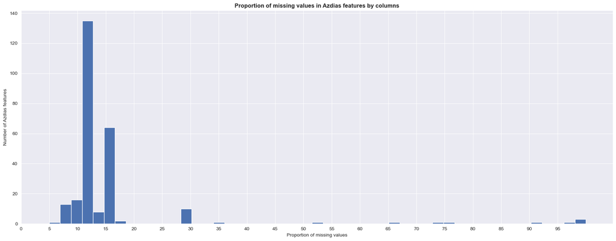

```python
plt.figure(figsize=(22,8))
#plt.subplots_adjust(hspace=0.5)
sb.set_theme({'axes.grid' : True})

df1_null_per = df1.isnull().mean()*100
#df2_null_per = df2.isnull().mean()*100

#plt.subplot(2, 1, 1)
plt.hist(df1_null_per, bins=np.linspace(5,100))
plt.xticks(np.arange(0, 100, 5))
plt.xlabel('Proportion of missing values')
plt.ylabel('Number of Azdias features')
plt.title('Proportion of missing values in Azdias features by columns', weight='bold')

#plt.subplot(2, 1, 2)
#plt.hist(df2_null_per, bins=np.linspace(5,100))
#plt.xticks(np.arange(0, 100, 5))
#plt.xlabel('Proportion of missing values （%）')
#plt.ylabel('Number of Customers features （%）')
#plt.title('Proportion of missing values in Customers features', weight='bold')
```

```python
# Check missing value of each column by percentage

for per in range (0,100,10):
    print ('Features in Azdias with missing values >', per,'%: ', len(df1_null_per[df1_null_per > per].index))

#print ('=='*30)

#for per in range (0,100,10):
#    print ('Features in Customers with missing values >', per,'%: ', len(df2_null_per[df2_null_per > per].index))

# Cols to drop in Azdias (df1)

#print ('=='*30)

#drop_null_cols = list(df1_null_per[df1_null_per>20].index)
#print("{} columns that have more than 20% missing values will be dropped: {}".format(len(drop_null_cols),drop_null_cols))
```

```
Features in Azdias with missing values > 0 %:  279
Features in Azdias with missing values > 10 %:  245
Features in Azdias with missing values > 20 %:  20
Features in Azdias with missing values > 30 %:  10
Features in Azdias with missing values > 40 %:  9
Features in Azdias with missing values > 50 %:  9
Features in Azdias with missing values > 60 %:  8
Features in Azdias with missing values > 70 %:  7
Features in Azdias with missing values > 80 %:  5
Features in Azdias with missing values > 90 %:  5
```

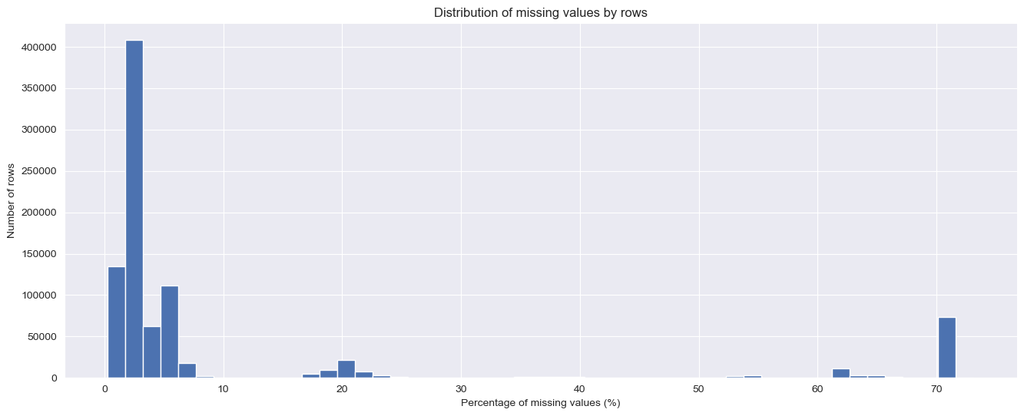

```python
# Plot distribution of missing values for rows

row_null_per = df1.isnull().mean(axis=1)*100
plt.figure(figsize=(16,6))
plt.hist(row_null_per, bins=np.linspace(min(row_null_per), max(row_null_per)+1))
#plt.hist(row_null_per, bins=40)

#plt.xticks(np.arange(min(row_null_per), max(row_null_per)+1, 10))
plt.ylabel('Number of rows')
plt.xlabel('Percentage of missing values (%)')
plt.title('Distribution of missing values by rows');
```

```python
cum_missing_rows_per_top30 = round(df1.isnull().sum(axis=1).value_counts().sort_index().cumsum()[:30] / len (df1) * 100,0)
print("The cumulative percentage of missing values for rows:", cum_missing_rows_per_top30)
```

```
The cumulative percentage of missing values for rows: 1      0.0
2      0.0
3      0.0
4      1.0
5      5.0
6     15.0
7     30.0
8     44.0
9     53.0
10    58.0
11    61.0
12    62.0
13    63.0
14    63.0
15    64.0
```

[output cut: 16 more lines]

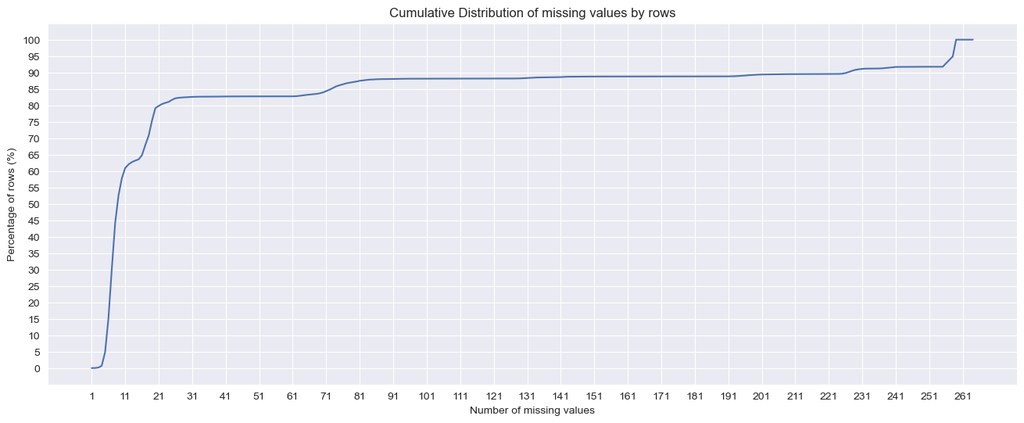

```python
missing_row_per = (df1.isnull().sum(axis=1).value_counts().sort_index().cumsum()/len(df1)) * 100
plt.figure(figsize=(16,6))
plt.plot(missing_row_per)

plt.yticks(np.arange(0, 100+5, 5))
plt.xticks(np.arange(min(missing_row_per .index), max(missing_row_per .index)+1, 10))
plt.ylabel('Percentage of rows (%)')
plt.xlabel('Number of missing values')
plt.title('Cumulative Distribution of missing values by rows')
plt.savefig('dist_missing_rows.png', dpi=500);
```

```python
# Check duplicates of df1 & df2 -- No duplicates are found

print (df1.duplicated().sum())
print (df2.duplicated().sum())
```

```
0
0
```

## Summary of Data Wranggling

> **In 'CAMEO_DEUG_2015' & 'CAMEO_INTL_2015':**
> - Convert "X" or "XX" as "Nan"

> **'CAMEO_INTL_2015' can be split into two seperated features:**

> > **"CAMEO_INTL_2015_WEALTH" (Based on the first digit of the origian value):**

> > ```
> > * 1: Wealthy <br>
> > * 2: Prosperous <br>
> > * 3: Comfortable <br>
> > * 4: Less Affluent <br>
> > * 5: Poor <br>
> > ```

> > **"CAMEO_INTL_2015_STATUS" (Based on the 2nd digit of the origin value):**

> > ```
> > * 1: Pre-Family Couples & Singles<br>
> > * 2: Young Couples With Children<br>
> > * 3: Families With School Age Children<br>
> > * 4: Older Families &  Mature Couples<br>
> > * 5: Elders In Retirement
> > ```

> **For feature 'OST_WEST_KZ':**
> - Convert: 0 = OST and 1 = WEST
> - Convert dtype as float

> **Columns to be removed:**
> - 'CAMEO_DEU_2015','D19_LETZTER_KAUF_BRANCHE', 'LNR' , 'EINGEFUEGT_AM'
> - "LP_LEBENSPHASE_FEIN", "LP_LEBENSPHASE_GROB", "LP_STATUS_FEIN" and "LP_FAMILIE_FEIN"
> - Columns with more than 20% of missing values

> **Remove rows with missing value

> **Feature Engineering:**
> - "LP_STATUS_GROB" and "LP_FAMILIE_GROB" can be re-encoded as below:
>   > - **"LP_STATUS_GROB"**  
>   >   1: low-income  
>   >   2: average-income  
>   >   3: independant  
>   >   4: houseowner  
>   >   5: top earner
>   > - **"LP_FAMILIE_GROB"**  
>   >   1: single  
>   >   2: couple  
>   >   3: single parent  
>   >   4: family  
>   >   5: multi-person household
>   > - **"PRAEGENDE_JUGENDJAHRE"** can be encoded into binaray (mainstream & avantgarde) from numeric values ranging from 1 to 15
>   > - **"WOHNLAGE"**  
>   >   1: Good Neighbourhood  
>   >   2: Average  
>   >   3: Poor Neighbourhood  
>   >   4: Rural

### Clean the dataframe

```python
per_missing_col = df1.isnull().mean()* 100
col_to_drop = per_missing_col[per_missing_col > 20].index
col_to_drop
```

```
Index(['AGER_TYP', 'ALTER_HH', 'ALTER_KIND1', 'ALTER_KIND2', 'ALTER_KIND3',
       'ALTER_KIND4', 'ALTERSKATEGORIE_FEIN', 'D19_BANKEN_ONLINE_QUOTE_12',
       'D19_GESAMT_ONLINE_QUOTE_12', 'D19_KONSUMTYP',
       'D19_LETZTER_KAUF_BRANCHE', 'D19_LOTTO', 'D19_SOZIALES',
       'D19_TELKO_ONLINE_QUOTE_12', 'D19_VERSAND_ONLINE_QUOTE_12',
       'D19_VERSI_ONLINE_QUOTE_12', 'EXTSEL992', 'KBA05_BAUMAX',
       'KK_KUNDENTYP', 'TITEL_KZ'],
      dtype='object')
```

```python
def clean_dataframe(df):

    # Drop columns above threshold (20%)
    df.drop(columns=col_to_drop, axis=1, inplace=True)

    # Drop rows above threshold (10%)
#    per_missing_row = df.isnull().mean(axis=1) * 100
#    df = df[per_missing_row <= n]
#    df.dropna(axis=0, inplace=True)

    # Convert 'X' and 'XX' as nan
    col = ["CAMEO_DEUG_2015", "CAMEO_INTL_2015"]
    df[col] = df[col].replace({"X": np.nan, "XX": np.nan})
    df[col] = df[col].astype(float)

    # re-encode binary categorical variables
    df['OST_WEST_KZ'].replace(['O','W'], [0, 1], inplace=True)
    df['OST_WEST_KZ'] = df['OST_WEST_KZ'].astype(float)


    # Remove uncecessary features
    df.drop(['CAMEO_DEU_2015', 'EINGEFUEGT_AM','LNR'], axis=1, inplace=True)

    # re-encode CAMEO_INTL_2015
    df['CAMEO_INTL_2015_WEALTH'] = df['CAMEO_INTL_2015'].apply(lambda x: np.floor(pd.to_numeric(x)/10))
    df['CAMEO_INTL_2015_STATUS'] = df['CAMEO_INTL_2015'].apply(lambda x: pd.to_numeric(x)%10)
    df.drop('CAMEO_INTL_2015', axis=1, inplace=True)

    # re-encode LP-related features and Wohn
    df = encode_lp_wohn(df)

    # Re-encode PRAEGENDE_JUGENDJAHRE
    df['PRAEGENDE_JUGENDJAHRE'] = df['PRAEGENDE_JUGENDJAHRE'].apply(lambda x: encode_pj(x))

    # Remove features if they are available
    try:
        df.drop(['PRODUCT_GROUP','CUSTOMER_GROUP','ONLINE_PURCHASE'], axis=1,inplace=True)
    except:
        pass

    # Drop rows with missing value
    df.dropna(axis=0, inplace=True)


    return df
```

```python
# Clean the datasets
df1_clean = clean_dataframe(df1)
df2_clean = clean_dataframe(df2)
```

```python
print ('The dimension of df1_clean:', df1_clean.shape)
print ('='*30)
print (df1_clean.info())
print ('='*30)
print ('The dimension of df2_clean:', df2_clean.shape)
print ('='*30)
print (df2_clean.info())
print ('='*30)
print (list(set(df1_clean)-set(df2_clean)))
```

```
The dimension of df1_clean: (613443, 340)
==============================
<class 'pandas.core.frame.DataFrame'>
Int64Index: 613443 entries, 1 to 891220
Columns: 340 entries, AKT_DAT_KL to CAMEO_INTL_2015_STATUS
dtypes: float64(340)
memory usage: 1.6 GB
None
==============================
The dimension of df2_clean: (115034, 340)
==============================
<class 'pandas.core.frame.DataFrame'>
Int64Index: 115034 entries, 0 to 191651
Columns: 340 entries, AKT_DAT_KL to CAMEO_INTL_2015_STATUS
dtypes: float64(340)
memory usage: 299.3 MB
None
==============================
[]
```

### Further removal of features with numeric values

For features with discrete values, correlation among variables is not necessarily to be checked since each discrete numeric digit represents a type of category. As a result, such features should be treated as categorical variables without onehot encoding.

In addition, features with continuous values should be reviewed. It would be too complex and time consuming to run algorithm mixing with too many continuous values and features with discrete values (encoded categorical variables).

Thus, I am going to find continuous value features by visual review and by mapping "meaning" based on numeric value. After the dataset is transformed based on below categoris, features with coninuous values shall be removed.

```python
# Get features with continuous values
numeric_feature = attributes_values[attributes_values['Meaning'].isin(['numeric value (typically coded from 1-10)',
                                                                       'numeric value (typically coded from 1-3)',
                                                                       'numeric value'])]

numeric_feature.Attribute.unique()
```

```
array(['ANZ_HAUSHALTE_AKTIV', 'ANZ_HH_TITEL', 'ANZ_PERSONEN', 'ANZ_TITEL',
       'GEBURTSJAHR', 'KBA13_ANZAHL_PKW', 'MIN_GEBAEUDEJAHR'],
      dtype=object)
```

```python
# Visual check features with continuous values

for col in df1_clean.columns:
    print(col, ': ', len(df1_clean[col].unique()), 'unique values, ', df1_clean[col].unique())
```

```
AKT_DAT_KL :  9 unique values,  [9. 1. 5. 8. 6. 4. 7. 2. 3.]
ANZ_HAUSHALTE_AKTIV :  279 unique values,  [ 11.  10.   3.   5.   4.   6.   2.   9.   1.  14.  13.   8.   7.  44.
  25. 272.  33.  15.  12.  22.  21.  20.  23.  18.   0.  24.  31.  39.
  16.  19.  30.  29.  17.  88.  49.  27.  38.  34.  35.  45.  28.  26.
  77.  47.  36.  43.  54.  52.  41.  40.  37.  59.  53.  57. 118.  32.
  50.  78.  42.  70.  73. 137.  80.  92.  94.  71.  66.  68.  81.  69.
  76.  95.  48.  46. 258. 124.  90. 128.  67.  64.  56.  83. 102. 150.
 236.  58. 259.  51. 160. 134. 169. 246.  82.  91. 114. 183.  86.  61.
 143.  99. 216.  98.  60. 125. 112. 123.  55. 120.  75. 141.  62.  72.
 103.  63.  85.  87. 223.  93. 179. 135. 126. 149.  97. 109. 121.  84.
 101. 367. 195.  89. 107. 119. 161. 157. 175. 136.  65. 116. 104. 316.
 127. 100. 155. 133. 178. 176. 110. 131. 122. 111. 130. 256. 117. 146.
  79. 211. 199. 140. 200. 108. 106. 285. 180. 163. 377.  74. 148. 191.
 243. 153. 145. 174. 172.  96. 190. 142. 317. 244. 189. 286. 170. 215.
 321. 171. 113. 156. 129. 242. 115. 132. 185. 280. 159. 138. 158. 267.
 253. 151. 164. 105. 187. 266. 162. 265. 139. 206. 193. 210. 366. 194.
 344. 154. 197. 247. 283. 184. 165. 326. 186. 438. 260. 144. 378. 152.
 208. 274. 430. 222. 202. 181. 214. 231. 219. 225. 230. 224. 333. 198.
 168. 221. 523. 254. 305. 166. 252. 445. 147. 301. 213. 536. 220. 290.
 515. 276. 241. 263. 196. 204. 250. 277. 218. 201. 240. 404. 348. 228.
 167. 346. 205. 207. 331. 255. 307. 414. 311. 347. 379. 395. 232.]
ANZ_HH_TITEL :  19 unique values,  [ 0.  1.  5.  2.  3.  6.  4.  9. 15. 14.  8.  7. 11. 10. 12. 13. 20. 16.
 18.]
ANZ_KINDER :  9 unique values,  [0. 1. 3. 2. 4. 5. 6. 7. 9.]
ANZ_PERSONEN :  24 unique values,  [ 2.  1.  4.  3.  5.  6.  8.  7. 12.  9. 21. 10. 13. 11. 14. 20. 31. 37.
 16. 22. 15. 18. 35. 38.]
ANZ_STATISTISCHE_HAUSHALTE :  252 unique values,  [ 12.   7.   3.   2.   5.   6.  14.   4.  11.   1.  13.  30.  22. 244.
  10.  32.   8.   9.  18.  17.  16.  19.  15.  20.  23.  33.  34.  68.
  21.  42.  28.  35.  29.  25.  26.  46.  48.  31.  27.  39.  40.  36.
  24.  56.  50.  37. 101.  44.  41.  43.  64.  38.  47.  57.  71. 131.
  74.  80.  94.  65.  60.  54.  87.  69.  82.  73.  72. 292.  83. 112.
  52.  75.  84. 140. 243. 212. 152. 142.  49. 166. 251.  70.  63. 107.
 173.  51. 138.  92. 154.  45. 115. 100.  55. 116. 125.  61.  88. 113.
  67.  91.  66.  86. 162.  95. 168.  62.  97. 110. 127.  89.  81.  76.
 111.  58. 114.  77.  98. 103. 365. 157. 109.  99.  59. 108. 130. 119.
 159. 117. 303. 137.  96.  79. 163.  90. 122. 156. 155.  53. 104. 223.
 105. 128. 217. 170. 218.  85.  78.  93. 132. 123. 328. 193. 126. 183.
 133. 153. 146. 121.   0. 233. 229. 134. 256. 180. 202. 118. 143. 136.
 106. 148. 204. 120. 245. 135. 248. 150. 102. 160. 164. 147. 139. 189.
 195. 269. 174. 129. 225. 314. 158. 141. 167. 354. 284. 264. 239. 238.
```

[output cut: 337 more lines]

```
 26. 21. 34. 44. 39. 45. 37. 41. 36. 38.]
VERS_TYP :  2 unique values,  [2. 1.]
VHA :  6 unique values,  [0. 5. 2. 1. 4. 3.]
VHN :  4 unique values,  [4. 2. 3. 1.]
VK_DHT4A :  11 unique values,  [ 8.  9.  3. 10.  7.  1.  6.  4.  2.  5. 11.]
VK_DISTANZ :  13 unique values,  [11.  9.  5.  7. 10. 12.  1. 13.  8.  3.  6.  4.  2.]
VK_ZG11 :  11 unique values,  [10.  6.  4.  9.  8.  1.  7.  5.  2.  3. 11.]
W_KEIT_KIND_HH :  6 unique values,  [3. 2. 6. 5. 4. 1.]
WOHNDAUER_2008 :  9 unique values,  [9. 8. 3. 6. 4. 2. 5. 7. 1.]
WOHNLAGE :  4 unique values,  [3. 1. 2. 4.]
ZABEOTYP :  6 unique values,  [5. 4. 1. 6. 3. 2.]
ANREDE_KZ :  2 unique values,  [2. 1.]
ALTERSKATEGORIE_GROB :  4 unique values,  [1. 3. 2. 4.]
CAMEO_INTL_2015_WEALTH :  5 unique values,  [5. 2. 4. 1. 3.]
CAMEO_INTL_2015_STATUS :  5 unique values,  [1. 4. 3. 2. 5.]
```

```python
# 'ANZ_STATISTISCHE_HAUSHALTE', 'VERDICHTUNGSRAUM', 'EINGEZOGENAM_HH_JAHR','KBA13_ANZAHL_PKW','MIN_GEBAEUDEJAHR'
# Above features are categorized as numeric variables via visual review

numeric_cols = ['ANZ_HAUSHALTE_AKTIV', 'ANZ_HH_TITEL', 'ANZ_PERSONEN', 'ANZ_TITEL',
                'GEBURTSJAHR', 'KBA13_ANZAHL_PKW', 'MIN_GEBAEUDEJAHR','ANZ_STATISTISCHE_HAUSHALTE',
               'VERDICHTUNGSRAUM','EINGEZOGENAM_HH_JAHR','KBA13_ANZAHL_PKW','MIN_GEBAEUDEJAHR']
```

```python
df1_clean.drop(columns=numeric_cols, inplace=True)
```

```python
df2_clean.drop(columns=numeric_cols, inplace=True)
```

```python
# Save the cleaned & scaled datasets
df1_clean.to_csv('/Users/johnma/Desktop/Udacity_Data Scientist/Project folder/Project 4_Capstone Project/data/Uazdias_clean.csv', index=False)
df2_clean.to_csv('/Users/johnma/Desktop/Udacity_Data Scientist/Project folder/Project 4_Capstone Project/data/Customers_clean.csv', index=False)
```

```python
#df1_clean = pd.read_csv('/Users/johnma/Desktop/Udacity_Data Scientist/Project folder/Project 4_Capstone Project/data/Uazdias_clean.csv')

#df2_clean = pd.read_csv('/Users/johnma/Desktop/Udacity_Data Scientist/Project folder/Project 4_Capstone Project/data/Customers_clean.csv')
```

```python
print ('The dimension of df1_clean:', df1_clean.shape)
print ('='*30)
print (df1_clean.info())
print ('='*30)
print ('The dimension of df2_clean:', df2_clean.shape)
print ('='*30)
print (df2_clean.info())
print ('='*30)
print (list(set(df1_clean)-set(df2_clean)))
```

```
The dimension of df1_clean: (613443, 330)
==============================
<class 'pandas.core.frame.DataFrame'>
Int64Index: 613443 entries, 1 to 891220
Columns: 330 entries, AKT_DAT_KL to CAMEO_INTL_2015_STATUS
dtypes: float64(330)
memory usage: 1.5 GB
None
==============================
The dimension of df2_clean: (115034, 330)
==============================
<class 'pandas.core.frame.DataFrame'>
Int64Index: 115034 entries, 0 to 191651
Columns: 330 entries, AKT_DAT_KL to CAMEO_INTL_2015_STATUS
dtypes: float64(330)
memory usage: 290.5 MB
None
==============================
[]
```

## Customer Segmentation Report

After the procedure above, only variables with encoded categorical features and binary features are reserved.  
Features with continuous values are removed since there are only 10 variables and would have limited impact for the modeling. Compared to the method of K-means whcih calculates Euclidean distance, K-modes replaces it with dissimilarity metric by using mode rathan than mean or median to represent the clusters. As a result, the method of K-modes is more appropriate to cope with cateforical datasets for further analysis.

Meanwhile, PCA (Principle Component Analysis) is not a proper tool for the datasets. Even though all the categorical and binary features are encoded with numeric values, PCA won’t be effective with encoded categorical variables due to lack of mathematical meaning for variance structure. It does not make sense to break down the variance for the numeric encoded values.

- Note: Since the datasets are too large and the limitation of calculation power of my personal laptop, it's time consuming for modeling and thus datasets are randomly selected 5K accordingly.

### Approach 1 -- K-modes based on "Cao"

```python
df1_clean = df1_clean.sample(5000, random_state=42)
df2_clean = df2_clean.sample(5000, random_state=42)
```

```python
# Convert dataframe to matrix
df1_matrix = df1_clean.loc[:, df1_clean.columns].to_numpy()
df1_matrix
```

```
array([[8., 1., 3., ..., 3., 1., 4.],
       [7., 0., 3., ..., 3., 2., 4.],
       [9., 0., 4., ..., 4., 1., 4.],
       ...,
       [1., 0., 2., ..., 4., 3., 2.],
       [9., 0., 4., ..., 1., 5., 2.],
       [9., 0., 3., ..., 2., 5., 1.]])
```

```
Init: initializing centroids
Init: initializing clusters
Starting iterations...
Run 1, iteration: 1/3, moves: 1418, cost: 836310.0
Run 1, iteration: 2/3, moves: 450, cost: 834903.0
Run 1, iteration: 3/3, moves: 304, cost: 834268.0
Init: initializing centroids
Init: initializing clusters
Starting iterations...
Run 1, iteration: 1/3, moves: 2177, cost: 803106.0
Run 1, iteration: 2/3, moves: 517, cost: 802525.0
Run 1, iteration: 3/3, moves: 202, cost: 802340.0
Init: initializing centroids
Init: initializing clusters
Starting iterations...
Run 1, iteration: 1/3, moves: 2384, cost: 784413.0
Run 1, iteration: 2/3, moves: 750, cost: 782056.0
Run 1, iteration: 3/3, moves: 473, cost: 780839.0
Init: initializing centroids
Init: initializing clusters
Starting iterations...
Run 1, iteration: 1/3, moves: 2400, cost: 780223.0
Run 1, iteration: 2/3, moves: 899, cost: 777600.0
Run 1, iteration: 3/3, moves: 511, cost: 776756.0
Init: initializing centroids
Init: initializing clusters
Starting iterations...
Run 1, iteration: 1/3, moves: 2531, cost: 773808.0
Run 1, iteration: 2/3, moves: 879, cost: 772080.0
Run 1, iteration: 3/3, moves: 518, cost: 770706.0
   Centroids      Cost
0         15  770706.0
1         12  776756.0
2         10  780839.0
3          5  802340.0
4          2  834268.0
```

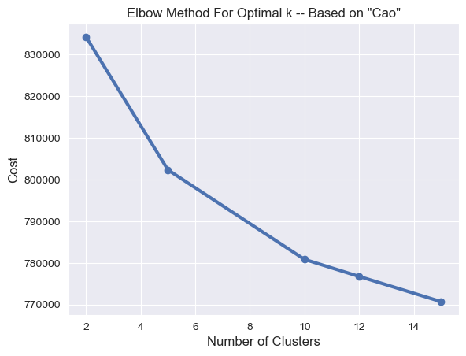

```python
# Choose the optimal K -- By "Cao"

cost = []
centroids = [2,5,10,12,15]

for cluster in centroids:
    kmode = KModes(n_clusters=cluster, init = 'Cao', n_init = 1,
                   verbose=1, max_iter=3,random_state = 42)
    kmode.fit_predict(df1_matrix)
    cost.append(kmode.cost_)

# Convert the results into a dataframe
print(pd.DataFrame(sorted(zip(centroids, cost), key=lambda x: x[1]), columns=['Centroids','Cost']))

# Plot
plt.plot(centroids,cost, linestyle='-', linewidth=3, marker='o')
plt.title('Elbow Method For Optimal k -- Based on "Cao"')
plt.xlabel('Number of Clusters', fontsize = 12)
plt.ylabel('Cost', fontsize = 12)
plt.show();
```

### Approach 2 -- K-modes based on "Huang"

```
Init: initializing centroids
Init: initializing clusters
Starting iterations...
Run 1, iteration: 1/3, moves: 1739, cost: 834960.0
Run 1, iteration: 2/3, moves: 549, cost: 833854.0
Run 1, iteration: 3/3, moves: 170, cost: 833758.0
Init: initializing centroids
Init: initializing clusters
Starting iterations...
Run 1, iteration: 1/3, moves: 2142, cost: 807543.0
Run 1, iteration: 2/3, moves: 616, cost: 806750.0
Run 1, iteration: 3/3, moves: 332, cost: 806148.0
Init: initializing centroids
Init: initializing clusters
Starting iterations...
Run 1, iteration: 1/3, moves: 2430, cost: 788481.0
Run 1, iteration: 2/3, moves: 995, cost: 784934.0
Run 1, iteration: 3/3, moves: 614, cost: 782737.0
Init: initializing centroids
Init: initializing clusters
Starting iterations...
Run 1, iteration: 1/3, moves: 2724, cost: 781421.0
Run 1, iteration: 2/3, moves: 973, cost: 779025.0
Run 1, iteration: 3/3, moves: 530, cost: 777729.0
Init: initializing centroids
Init: initializing clusters
Starting iterations...
Run 1, iteration: 1/3, moves: 2837, cost: 776694.0
Run 1, iteration: 2/3, moves: 1195, cost: 774015.0
Run 1, iteration: 3/3, moves: 593, cost: 772688.0
   Centroids      Cost
0         15  772688.0
1         12  777729.0
2         10  782737.0
3          5  806148.0
4          2  833758.0
```

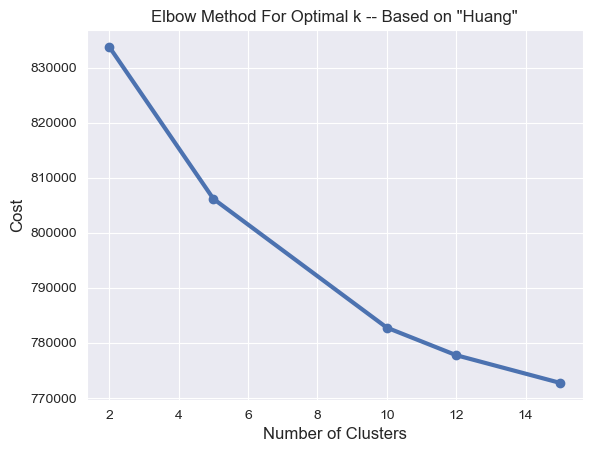

```python
# Choose the optimal K -- By "Huang"

cost = []
centroids = [2,5,10,12,15]

for cluster in centroids:
    kmode = KModes(n_clusters=cluster, init = 'Huang', n_init = 1,
                   verbose=1, max_iter=3, random_state = 42)
    kmode.fit_predict(df1_matrix)
    cost.append(kmode.cost_)

# Convert the results into a dataframe
print(pd.DataFrame(sorted(zip(centroids, cost), key=lambda x: x[1]), columns=['Centroids','Cost']))

# Plot
plt.plot(centroids,cost, linestyle='-', linewidth=3, marker='o')
plt.title('Elbow Method For Optimal k -- Based on "Huang"')
plt.xlabel('Number of Clusters', fontsize = 12)
plt.ylabel('Cost', fontsize = 12)
plt.show();
```

### Evaluation

> - The Elbow method is applied to determine the optimal number of clusters. Two approches with "Cao" and "Huang" are used to evalute which algorithm would lead to a more reasonable result.
> - Both methods suggest similar results that I would take "5" as the optimal number of K to proceed

### Interpretation of K-modes Clustering (k=5)

### Fit k-modes into df1 (Azdias)

```python
# Convert dataframes to matrix
df1Matrix = df1_clean.to_numpy()
df2Matrix = df2_clean.to_numpy()
```

```python
kmodes = KModes(n_clusters = 5, init = 'Huang',n_init = 1,
                verbose=1, max_iter=3, random_state = 42)

# Fit the model
y_pred_df1 = kmodes.fit_predict(df1Matrix)

# Create "cluster_id" column in the dataframe
df1_clean['cluster_id']= kmodes.labels_
df1_sort_cluster_id = df1_clean.cluster_id.value_counts().sort_index()
```

```
Init: initializing centroids
Init: initializing clusters
Starting iterations...
Run 1, iteration: 1/3, moves: 2142, cost: 807543.0
Run 1, iteration: 2/3, moves: 616, cost: 806750.0
Run 1, iteration: 3/3, moves: 332, cost: 806148.0
```

```python
print (df1_sort_cluster_id)
```

```
0    1287
1    1043
2    1091
3     818
4     761
Name: cluster_id, dtype: int64
```

### Prediction of df2 (Customers)

```python
# Predict trained model on customers dataset
y_pred_df2 = kmodes.predict(df2Matrix)
```

```python
df2_clean['cluster_id'] = y_pred_df2
```

```python
df2_clean.head()
```

|  | AKT_DAT_KL | ANZ_KINDER | ARBEIT | BALLRAUM | CAMEO_DEUG_2015 | CJT_GESAMTTYP | CJT_KATALOGNUTZER | CJT_TYP_1 | CJT_TYP_2 | CJT_TYP_3 | CJT_TYP_4 | CJT_TYP_5 | CJT_TYP_6 | D19_BANKEN_ANZ_12 | D19_BANKEN_ANZ_24 | D19_BANKEN_DATUM | D19_BANKEN_DIREKT | D19_BANKEN_GROSS | D19_BANKEN_LOKAL | D19_BANKEN_OFFLINE_DATUM | D19_BANKEN_ONLINE_DATUM | D19_BANKEN_REST | D19_BEKLEIDUNG_GEH | D19_BEKLEIDUNG_REST | D19_BILDUNG | D19_BIO_OEKO | D19_BUCH_CD | D19_DIGIT_SERV | D19_DROGERIEARTIKEL | … |
| --- | --- | --- | --- | --- | --- | --- | --- | --- | --- | --- | --- | --- | --- | --- | --- | --- | --- | --- | --- | --- | --- | --- | --- | --- | --- | --- | --- | --- | --- | --- |
| 95241 | 1.0 | 0.0 | 4.0 | 1.0 | 4.0 | 2.0 | 5.0 | 2.0 | 1.0 | 5.0 | 5.0 | 5.0 | 5.0 | 0.0 | 0.0 | 10.0 | 0.0 | 0.0 | 0.0 | 10.0 | 10.0 | 0.0 | 0.0 | 0.0 | 0.0 | 0.0 | 0.0 | 0.0 | 0.0 | … |
| 9173 | 1.0 | 0.0 | 3.0 | 6.0 | 1.0 | 2.0 | 5.0 | 2.0 | 1.0 | 5.0 | 5.0 | 5.0 | 5.0 | 0.0 | 0.0 | 10.0 | 0.0 | 0.0 | 0.0 | 10.0 | 10.0 | 0.0 | 6.0 | 0.0 | 0.0 | 0.0 | 6.0 | 0.0 | 0.0 | … |
| 64470 | 1.0 | 0.0 | 3.0 | 1.0 | 7.0 | 3.0 | 5.0 | 1.0 | 2.0 | 5.0 | 5.0 | 5.0 | 5.0 | 0.0 | 0.0 | 10.0 | 0.0 | 0.0 | 0.0 | 10.0 | 10.0 | 0.0 | 0.0 | 0.0 | 0.0 | 0.0 | 0.0 | 0.0 | 0.0 | … |
| 159885 | 1.0 | 0.0 | 4.0 | 3.0 | 7.0 | 4.0 | 5.0 | 1.0 | 1.0 | 5.0 | 5.0 | 5.0 | 5.0 | 0.0 | 0.0 | 10.0 | 0.0 | 0.0 | 0.0 | 10.0 | 10.0 | 0.0 | 0.0 | 0.0 | 0.0 | 0.0 | 0.0 | 0.0 | 0.0 | … |
| 3205 | 2.0 | 0.0 | 2.0 | 3.0 | 3.0 | 3.0 | 5.0 | 2.0 | 2.0 | 5.0 | 5.0 | 5.0 | 5.0 | 0.0 | 0.0 | 10.0 | 0.0 | 0.0 | 0.0 | 10.0 | 10.0 | 0.0 | 0.0 | 6.0 | 0.0 | 0.0 | 0.0 | 0.0 | 0.0 | … |

```python
df2_clean.cluster_id.value_counts().sort_index()
```

```
0     820
1     252
2     471
3    2029
4    1428
Name: cluster_id, dtype: int64
```

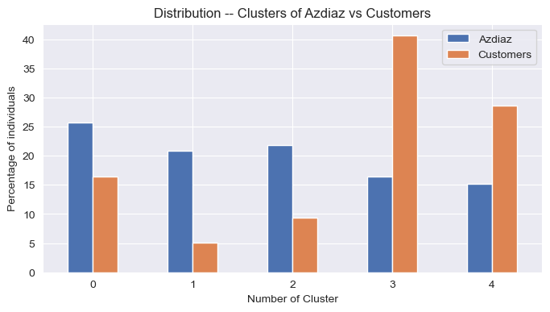

|  | Azdiaz | Customers |
| --- | --- | --- |
| 0 | 25.74 | 16.40 |
| 1 | 20.86 | 5.04 |
| 2 | 21.82 | 9.42 |
| 3 | 16.36 | 40.58 |
| 4 | 15.22 | 28.56 |

```python
clusters_dict = {
    'Azdiaz': df1_clean.cluster_id.value_counts().sort_index() / df1_clean.shape[0] *100,
    'Customers': df2_clean.cluster_id.value_counts().sort_index() / df1_clean.shape[0] *100
}

df_clusters = pd.DataFrame(clusters_dict)

# making plot
ax = df_clusters.plot.bar(rot=0, figsize=(8,4))
ax.set_title('Distribution -- Clusters of Azdiaz vs Customers')
ax.set_xlabel('Number of Cluster')
ax.set_ylabel('Percentage of individuals')
plt.show();


df_clusters
```

```python
# columns for centroids
cluster_col = ['cluster_id']
cols = [col for col in df1_clean if col not in cluster_col]

# make index for cluster interpretation
index = ['cluster_0', 'cluster_1', 'cluster_2', 'cluster_3', 'cluster_4']

# make dataframe
df_clusters_centroids = pd.DataFrame(kmodes.cluster_centroids_, columns = cols, index = index)
df_clusters_centroids
```

|  | AKT_DAT_KL | ANZ_KINDER | ARBEIT | BALLRAUM | CAMEO_DEUG_2015 | CJT_GESAMTTYP | CJT_KATALOGNUTZER | CJT_TYP_1 | CJT_TYP_2 | CJT_TYP_3 | CJT_TYP_4 | CJT_TYP_5 | CJT_TYP_6 | D19_BANKEN_ANZ_12 | D19_BANKEN_ANZ_24 | D19_BANKEN_DATUM | D19_BANKEN_DIREKT | D19_BANKEN_GROSS | D19_BANKEN_LOKAL | D19_BANKEN_OFFLINE_DATUM | D19_BANKEN_ONLINE_DATUM | D19_BANKEN_REST | D19_BEKLEIDUNG_GEH | D19_BEKLEIDUNG_REST | D19_BILDUNG | D19_BIO_OEKO | D19_BUCH_CD | D19_DIGIT_SERV | D19_DROGERIEARTIKEL | … |
| --- | --- | --- | --- | --- | --- | --- | --- | --- | --- | --- | --- | --- | --- | --- | --- | --- | --- | --- | --- | --- | --- | --- | --- | --- | --- | --- | --- | --- | --- | --- |
| cluster_0 | 1.0 | 0.0 | 3.0 | 6.0 | 4.0 | 4.0 | 1.0 | 5.0 | 4.0 | 3.0 | 2.0 | 4.0 | 2.0 | 0.0 | 0.0 | 10.0 | 0.0 | 0.0 | 0.0 | 10.0 | 10.0 | 0.0 | 0.0 | 0.0 | 0.0 | 0.0 | 0.0 | 0.0 | 0.0 | … |
| cluster_1 | 9.0 | 0.0 | 4.0 | 1.0 | 9.0 | 4.0 | 4.0 | 5.0 | 5.0 | 1.0 | 3.0 | 2.0 | 2.0 | 0.0 | 0.0 | 10.0 | 0.0 | 0.0 | 0.0 | 10.0 | 10.0 | 0.0 | 0.0 | 0.0 | 0.0 | 0.0 | 0.0 | 0.0 | 0.0 | … |
| cluster_2 | 1.0 | 0.0 | 4.0 | 6.0 | 8.0 | 4.0 | 5.0 | 3.0 | 3.0 | 2.0 | 3.0 | 3.0 | 4.0 | 0.0 | 0.0 | 10.0 | 0.0 | 0.0 | 0.0 | 10.0 | 10.0 | 0.0 | 0.0 | 0.0 | 0.0 | 0.0 | 0.0 | 0.0 | 0.0 | … |
| cluster_3 | 1.0 | 0.0 | 3.0 | 6.0 | 2.0 | 2.0 | 5.0 | 2.0 | 1.0 | 5.0 | 5.0 | 5.0 | 5.0 | 0.0 | 0.0 | 10.0 | 0.0 | 0.0 | 0.0 | 10.0 | 10.0 | 0.0 | 0.0 | 0.0 | 0.0 | 0.0 | 0.0 | 0.0 | 0.0 | … |
| cluster_4 | 1.0 | 0.0 | 4.0 | 6.0 | 6.0 | 2.0 | 5.0 | 1.0 | 1.0 | 5.0 | 5.0 | 5.0 | 5.0 | 0.0 | 0.0 | 10.0 | 0.0 | 0.0 | 0.0 | 10.0 | 10.0 | 0.0 | 0.0 | 0.0 | 0.0 | 0.0 | 0.0 | 0.0 | 0.0 | … |

```python
df1_centroids = df_clusters_centroids.loc[(df_clusters_centroids.index == 'cluster_0') | (df_clusters_centroids.index == 'cluster_1') | (df_clusters_centroids.index == 'cluster_2')]
df2_centroids = df_clusters_centroids.loc[(df_clusters_centroids.index == 'cluster_3') | (df_clusters_centroids.index == 'cluster_4') ]
```

```python
center_dict = {'Population': list(df1_centroids.mean().round(2)),
              'Customers': list(df2_centroids.mean().round(2))}
```

```python
df_center = pd.DataFrame(center_dict, columns = ['Population', 'Customers'], index = df_clusters_centroids.columns)
```

```python
df_center.head()
```

|  | Population | Customers |
| --- | --- | --- |
| AKT_DAT_KL | 3.67 | 1.0 |
| ANZ_KINDER | 0.00 | 0.0 |
| ARBEIT | 3.67 | 3.5 |
| BALLRAUM | 4.33 | 6.0 |
| CAMEO_DEUG_2015 | 7.00 | 4.0 |

> - Clearly, cluster 3 and 4 show a strong representation of the customers compared to the population.
> - Meanwhile, clusters 0,1,2 are the ones with less power of representativity to the customers.
> - Based on the process above, the demographic features for the centroids of each cluster are presented. That is, the characteristics of potential clients can be determined when the features of cluster 3 and 4 are examined. On the contrary, for those who may not be the customers could be justified when cluster 0, 1 and 2 are reviewed.
> - For example, the interested cluster would be:
>   1. Middle class who are consumption-oriented
>   2. distance to the next urban center is 50-60km
>   - Note: "AKT_DAT_KL", "ANZ_KINDER", and "ARBEIT" are not described in the sheet of "DIAS Attributes -- Values 2017".

## Supervised Learning Model

```python
df_train = pd.read_csv('/Users/johnma/Desktop/Udacity_Data Scientist/Project folder/Project 4_Capstone Project/data/Udacity_MAILOUT_052018_TRAIN.csv', sep=';')
```

```python
print ('Show data info of Udacity_MAILOUT_052018_TRAIN')
print ('==============================')
print (df_train.info())
```

```
Show data info of Udacity_MAILOUT_052018_TRAIN
==============================
<class 'pandas.core.frame.DataFrame'>
RangeIndex: 42962 entries, 0 to 42961
Columns: 367 entries, LNR to ALTERSKATEGORIE_GROB
dtypes: float64(267), int64(94), object(6)
memory usage: 120.3+ MB
None
```

```
0    42430
1      532
Name: RESPONSE, dtype: int64

0    0.987617
1    0.012383
Name: RESPONSE, dtype: float64
```

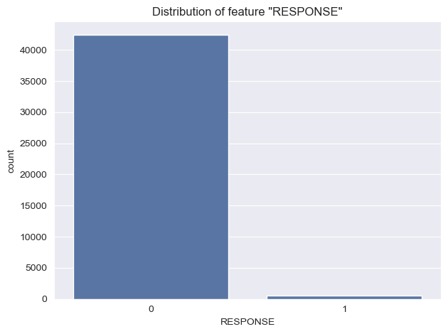

```python
# Count plot of RESPONSE
print(df_train.RESPONSE.value_counts())
print('')
print(df_train.RESPONSE.value_counts() / np.sum(df_train.RESPONSE.value_counts()))


base_color = sb.color_palette()[0]
sb.countplot("RESPONSE", data=df_train, color = base_color)
plt.title('Distribution of feature "RESPONSE"')
plt.xlabel('RESPONSE')
plt.tight_layout();
```

> According to the information above, the target value is highly imbalance, with merely around 1% feedback become a client.

### Data wranggling for the training dataset

```python
# Convert missing and unknown values to nan values
# attributes_values = attributes_values[attributes_values.columns[1:]]

attributes_values = attributes_values[attributes_values['Attribute'].notnull()]
unknown = attributes_values[attributes_values['Meaning'].isin(['unknown', 'unknown / no main age detectable'])]

for col in df_train.columns:
    if df_train[col].dtype == np.int64:
        df_train[col] = df_train[col].astype(np.float64)
    if col not in set(unknown['Attribute']):
        continue

    unknown_value = unknown.loc[unknown['Attribute'] == col].Value.item()
    unknown_value = set(float(x) for x in unknown_value.split(', ')) if type(unknown_value) is str else set([float(unknown_value)])
    df_train[col] = df_train[col].mask(df_train[col].isin(unknown_value), other=np.nan)
```

```python
percent_missing_col_train = df_train.isnull().mean() * 100
col_to_drop_train = percent_missing_col_train [percent_missing_col_train  > 20].index
print ("Number of cols to drop:",len (col_to_drop_train))
```

```
Number of cols to drop: 77
```

```python
def clean_supervised_dataframe(df, attributes_values, col_to_drop_train):

    # Drop columns above threshold (20%)
#    df.drop(columns=col_to_drop_train, axis=1, inplace=True)

    # Drop numeric cols
    df.drop(columns=numeric_cols, axis=1, inplace=True)

    # Convert 'X' and 'XX' as nan
    col = ["CAMEO_DEUG_2015", "CAMEO_INTL_2015"]
    df[col] = df[col].replace({"X": np.nan, "XX": np.nan})
    df[col] = df[col].astype(float)

    # re-encode binary categorical variables
    df['OST_WEST_KZ'].replace(['O','W'], [0, 1], inplace=True)
    df['OST_WEST_KZ'] = df['OST_WEST_KZ'].astype(float)


    # Remove uncecessary features
    ##"ALTER_HH", "ALTERSKATEGORIE_FEIN" are removed based on visual check (due to too many unique values)
    df.drop(['CAMEO_DEU_2015', 'EINGEFUEGT_AM',
             'D19_LETZTER_KAUF_BRANCHE',"ALTERSKATEGORIE_FEIN"], axis=1, inplace=True)

    # re-encode CAMEO_INTL_2015
    df['CAMEO_INTL_2015_WEALTH'] = df['CAMEO_INTL_2015'].apply(lambda x: np.floor(pd.to_numeric(x)/10))
    df['CAMEO_INTL_2015_STATUS'] = df['CAMEO_INTL_2015'].apply(lambda x: pd.to_numeric(x)%10)
    df.drop('CAMEO_INTL_2015', axis=1, inplace=True)

    # re-encode LP-related features and Wohn
    df = encode_lp_wohn(df)

    # Re-encode PRAEGENDE_JUGENDJAHRE
    df['PRAEGENDE_JUGENDJAHRE'] = df['PRAEGENDE_JUGENDJAHRE'].apply(lambda x: encode_pj(x))

    # Remove features if they are available
    try:
        df.drop(['PRODUCT_GROUP','CUSTOMER_GROUP','ONLINE_PURCHASE'], axis=1,inplace=True)
    except:
        pass

    # Convert features dtype==int64 to float
    col_int = df.columns[df.dtypes.eq('int64')]
    df[col_int] = df[col_int].astype(float)

    # Drop columns above threshold (20%)
    df.drop(columns=col_to_drop_train, axis=1, inplace=True)

    # Drop rows with missing values
    df.dropna(axis=0, inplace=True)

    return df

df_train = clean_supervised_dataframe(df_train, attributes_values, col_to_drop_train)
```

```python
# "LNR" is a unique number of client identificaion and should be droped to avoid training

df_train.drop(columns='LNR', inplace=True)
```

```python
print ('Show data info of Udacity_MAILOUT_052018_TRAIN')
print ('==============================')
print (df_train.info())
```

```
Show data info of Udacity_MAILOUT_052018_TRAIN
==============================
<class 'pandas.core.frame.DataFrame'>
Int64Index: 29940 entries, 0 to 42961
Columns: 272 entries, AKT_DAT_KL to CAMEO_INTL_2015_STATUS
dtypes: float64(272)
memory usage: 62.4 MB
None
```

```python
# Visual check whether features with continuous values

for col in df_train.columns:
    print(col, ': ', len(df_train[col].unique()), 'unique values, ', df_train[col].unique())
```

```
AKT_DAT_KL :  9 unique values,  [1. 4. 7. 5. 9. 3. 2. 6. 8.]
ANZ_KINDER :  7 unique values,  [0. 1. 2. 4. 3. 5. 6.]
ARBEIT :  6 unique values,  [3. 2. 4. 1. 5. 9.]
BALLRAUM :  7 unique values,  [5. 2. 4. 1. 6. 7. 3.]
CAMEO_DEUG_2015 :  9 unique values,  [5. 2. 7. 4. 3. 6. 1. 8. 9.]
CJT_GESAMTTYP :  6 unique values,  [2. 6. 4. 1. 3. 5.]
CJT_KATALOGNUTZER :  5 unique values,  [5. 2. 3. 4. 1.]
CJT_TYP_1 :  5 unique values,  [2. 1. 3. 5. 4.]
CJT_TYP_2 :  5 unique values,  [2. 3. 1. 4. 5.]
CJT_TYP_3 :  5 unique values,  [5. 4. 3. 2. 1.]
CJT_TYP_4 :  5 unique values,  [5. 3. 2. 4. 1.]
CJT_TYP_5 :  5 unique values,  [5. 3. 4. 2. 1.]
CJT_TYP_6 :  5 unique values,  [5. 4. 3. 1. 2.]
D19_BANKEN_ANZ_12 :  7 unique values,  [0. 1. 3. 2. 4. 5. 6.]
D19_BANKEN_ANZ_24 :  7 unique values,  [0. 1. 2. 5. 4. 3. 6.]
D19_BANKEN_DATUM :  10 unique values,  [10.  5.  7.  9.  2.  8.  3.  4.  6.  1.]
D19_BANKEN_DIREKT :  8 unique values,  [0. 4. 6. 5. 3. 1. 2. 7.]
D19_BANKEN_GROSS :  7 unique values,  [0. 6. 2. 3. 5. 1. 4.]
D19_BANKEN_LOKAL :  8 unique values,  [0. 3. 7. 6. 5. 4. 2. 1.]
D19_BANKEN_OFFLINE_DATUM :  10 unique values,  [10.  8.  5.  9.  1.  2.  6.  4.  3.  7.]
D19_BANKEN_ONLINE_DATUM :  10 unique values,  [10.  7.  9.  2.  3.  8.  5.  6.  1.  4.]
D19_BANKEN_ONLINE_QUOTE_12 :  8 unique values,  [ 0. 10.  3.  5.  9.  7.  8.  2.]
D19_BANKEN_REST :  8 unique values,  [0. 6. 5. 7. 3. 1. 2. 4.]
D19_BEKLEIDUNG_GEH :  8 unique values,  [0. 5. 1. 6. 4. 3. 2. 7.]
D19_BEKLEIDUNG_REST :  8 unique values,  [0. 6. 7. 2. 3. 5. 4. 1.]
D19_BILDUNG :  8 unique values,  [0. 7. 6. 5. 2. 3. 4. 1.]
D19_BIO_OEKO :  7 unique values,  [0. 7. 6. 5. 3. 4. 2.]
D19_BUCH_CD :  8 unique values,  [0. 6. 3. 5. 1. 4. 2. 7.]
D19_DIGIT_SERV :  8 unique values,  [0. 3. 6. 2. 7. 5. 4. 1.]
D19_DROGERIEARTIKEL :  8 unique values,  [0. 6. 5. 4. 7. 3. 1. 2.]
D19_ENERGIE :  8 unique values,  [0. 3. 2. 6. 5. 7. 1. 4.]
D19_FREIZEIT :  8 unique values,  [0. 3. 6. 5. 2. 4. 7. 1.]
D19_GARTEN :  8 unique values,  [0. 6. 5. 3. 7. 2. 1. 4.]
D19_GESAMT_ANZ_12 :  7 unique values,  [0. 2. 3. 1. 4. 5. 6.]
D19_GESAMT_ANZ_24 :  7 unique values,  [0. 2. 1. 4. 5. 6. 3.]
D19_GESAMT_DATUM :  10 unique values,  [ 9.  1. 10.  7.  2.  8.  4.  5.  6.  3.]
D19_GESAMT_OFFLINE_DATUM :  10 unique values,  [ 9.  1. 10.  7.  4.  8.  6.  5.  2.  3.]
D19_GESAMT_ONLINE_DATUM :  10 unique values,  [ 9.  8. 10.  2.  7.  4.  5.  1.  6.  3.]
D19_GESAMT_ONLINE_QUOTE_12 :  11 unique values,  [ 0.  6. 10.  7.  5.  9.  3.  2.  8.  4.  1.]
D19_HANDWERK :  8 unique values,  [0. 6. 7. 3. 5. 4. 1. 2.]
```

[output cut: 217 more lines]

```
UNGLEICHENN_FLAG :  2 unique values,  [0. 1.]
VERS_TYP :  2 unique values,  [2. 1.]
VHA :  6 unique values,  [1. 0. 5. 4. 3. 2.]
VHN :  5 unique values,  [2. 3. 4. 1. 0.]
VK_DHT4A :  11 unique values,  [ 5.  1.  8.  2.  6.  7.  3. 10.  9.  4. 11.]
VK_DISTANZ :  13 unique values,  [ 2. 11.  1.  6.  8.  4.  3.  5.  7. 12. 10.  9. 13.]
VK_ZG11 :  11 unique values,  [ 1. 11.  3.  5.  2.  4.  9.  7.  6. 10.  8.]
WOHNDAUER_2008 :  9 unique values,  [9. 6. 8. 5. 7. 4. 3. 1. 2.]
WOHNLAGE :  4 unique values,  [2. 4. 1. 3.]
ZABEOTYP :  6 unique values,  [3. 1. 4. 6. 2. 5.]
RESPONSE :  2 unique values,  [0. 1.]
ANREDE_KZ :  2 unique values,  [2. 1.]
ALTERSKATEGORIE_GROB :  4 unique values,  [4. 3. 2. 1.]
CAMEO_INTL_2015_WEALTH :  5 unique values,  [3. 1. 4. 2. 5.]
CAMEO_INTL_2015_STATUS :  5 unique values,  [4. 2. 1. 3. 5.]
```

```python
# Save the cleaned training dataset
df_train.to_csv('/Users/johnma/Desktop/Udacity_Data Scientist/Project folder/Project 4_Capstone Project/data/df_train.csv', index=False)
```

```python
#df_train = pd.read_csv('/Users/johnma/Desktop/Udacity_Data Scientist/Project folder/Project 4_Capstone Project/data/df_train.csv')
```

### Model Training

The dataset shows a problem of classification. Thus, few classifiers are used in later modeling for the prediction of whether an individual becomes a customer of the campaign.

**Metrics of evaluation**  
The evaluation metric for this interested task is AUC for the ROC curve, relative to the detection of customers from the mail campaign.

A receiver operating characteristic (ROC) curve is a graphic plot used to demonstrate the true positive rate (TPR, also known as recall, which is the proportion of correctly labeled actual customers) against the false positive rate (FPR, proportion of non-customers labeled as customers).

Mathematical formulas of TPR and FPR are defined as:

TPR = TP / (TP + FN)  
FPR = FP /(FP + TN)

where

TP = ture positive

FP = false postive

TN = true negative

FN = false negative

**Improvement of the seleceted algorithms**  
The ROC score of each algorithm and the time of training are considered as major criteria whether the model would be applied. The tenique of GriedSearch will be applied fo find out the best combination of parameters. Such hyper-tuning would further improve the performance of the models.

```python
# Randomly take 80% of original data as sample
df_train = df_train.sample(frac=0.8)
```

```python
X = df_train.iloc[:, df_train.columns != 'RESPONSE']
y = df_train['RESPONSE']
```

```python
# Scale the data
scaler= StandardScaler()
X_train = scaler.fit_transform(X)
```

```python
# Split the dataset into Train and Test set
X_train, X_test, y_train, y_test = train_test_split(X, y, test_size=0.20, random_state=42)
```

```python
# Classifiers to check the performance
Classifiers = [("Logistic Regression", LogisticRegression(random_state=42)),
         ("Decision Tree", DecisionTreeClassifier(random_state=42)),
         ("Random Forest", RandomForestClassifier(random_state=42)),
         ("Gradient Boosting", GradientBoostingClassifier(random_state=42)),
         ("AdaBoost", AdaBoostClassifier(random_state=42))]
```

```python
# Funciton application
test_model(Classifiers, X_train, y_train, X_test, y_test)
```

|  | Training Model | ROC Score | Training Time |
| --- | --- | --- | --- |
| 0 | Logistic Regression | 0.66174 | 0.490284 |
| 1 | Decision Tree | 0.506458 | 0.722162 |
| 2 | Random Forest | 0.578227 | 3.23643 |
| 3 | Gradient Boosting | 0.759561 | 18.53092 |
| 4 | AdaBoost | 0.731138 | 4.268291 |

> The table above demonstrates the ROC score of each classifier. Compared to the benchmark model (Logistic Regression), the GradientBoostingClassifier shows the highest score, while it also takes the most time for training. The AdaBoost reveals the 2nd best score and takes less time to train. As a result, I would choose these two classifiers (GradientBoosting & AdaBoost) for hyper parameter tuning.

### Hyper Tuning -- Grid Search

### GradientBoost Classifier

```python
# Grid serach for GradientBoostClassifier model
# I've choose the paramters after browes this article.
# https://www.analyticsvidhya.com/blog/2016/02/complete-guide-parameter-tuning-gradient-boosting-gbm-python/
# The values of the parameter are basically used by try & error

gbc = GradientBoostingClassifier(random_state=42)

parameters_gbc = {'subsample': [0.8],
              'n_estimators': [100],
              'max_depth': [8],
              'min_samples_split': [2, 4],
              'learning_rate': [0.1, 0.2]
             }
```

```python
# Fit the grid search object to the training data and find the optimal parameters
gbc_grid = GridSearchCV(gbc, parameters_gbc, scoring = 'roc_auc', verbose=2, cv=2)

gbc_grid.fit(X_train, y_train)
```

```
Fitting 2 folds for each of 4 candidates, totalling 8 fits
[CV] END learning_rate=0.1, max_depth=8, min_samples_split=2, n_estimators=100, subsample=0.8; total time=  21.2s
[CV] END learning_rate=0.1, max_depth=8, min_samples_split=2, n_estimators=100, subsample=0.8; total time=  21.3s
[CV] END learning_rate=0.1, max_depth=8, min_samples_split=4, n_estimators=100, subsample=0.8; total time=  20.9s
[CV] END learning_rate=0.1, max_depth=8, min_samples_split=4, n_estimators=100, subsample=0.8; total time=  24.1s
[CV] END learning_rate=0.2, max_depth=8, min_samples_split=2, n_estimators=100, subsample=0.8; total time=  26.6s
[CV] END learning_rate=0.2, max_depth=8, min_samples_split=2, n_estimators=100, subsample=0.8; total time=  21.5s
[CV] END learning_rate=0.2, max_depth=8, min_samples_split=4, n_estimators=100, subsample=0.8; total time=  21.2s
[CV] END learning_rate=0.2, max_depth=8, min_samples_split=4, n_estimators=100, subsample=0.8; total time=  24.7s
```

```
GridSearchCV(cv=2, estimator=GradientBoostingClassifier(random_state=42),
             param_grid={'learning_rate': [0.1, 0.2], 'max_depth': [8],
                         'min_samples_split': [2, 4], 'n_estimators': [100],
                         'subsample': [0.8]},
             scoring='roc_auc', verbose=2)
```

```
Best Params:  {'learning_rate': 0.1, 'max_depth': 8, 'min_samples_split': 2, 'n_estimators': 100, 'subsample': 0.8}
ROC score on testing data: 0.4984
Accuracy Score:0.9829

Classification report
              precision    recall  f1-score   support

         0.0       0.99      1.00      0.99      4724
         1.0       0.00      0.00      0.00        67

    accuracy                           0.98      4791
   macro avg       0.49      0.50      0.50      4791
weighted avg       0.97      0.98      0.98      4791
```

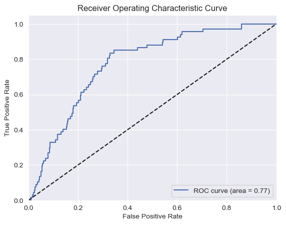

```python
# Get the best parameter

print("Best Params: ", gbc_grid.best_params_)
best_clf_gbc = gbc_grid.best_estimator_

# Predict the tuned model
pred_gbc = best_clf_gbc.predict(X_test)

print("ROC score on testing data: {:.4f}".format(roc_auc_score(y_test, pred_gbc)))



# Print Accuracy Score
print ("Accuracy Score:{:.4f}".format(accuracy_score(y_test,pred_gbc)))
print ('')

# Classification report
print("Classification report")
print(classification_report(y_test, pred_gbc))
print ('')

# Evaluate the model
evaluate_model_ROC(best_clf_gbc, X_test, y_test)
```

### AdaBoost Classifier

```python
# Check the paramters of ADAboost
#clf_ada = AdaBoostClassifier()
#clf_ada.get_params().keys()
```

```python
# The parameters are refered to this article:
# https://www.kaggle.com/code/juanmah/tactic-03-hyperparameter-optimization-adaboost
# I've slightly revise the value based on try & error

# Grid serach for AdaBoostClassifier model
clf_ada = AdaBoostClassifier(random_state=42)

parameters = {
    'n_estimators': [8, 9, 10],
    'learning_rate': [(0.97 + x / 100) for x in range(0, 7)],
    'algorithm': ['SAMME']
}

# Fit the grid search object to the training data and find the optimal parameters
clf_ada_grid = GridSearchCV(clf_ada, parameters, scoring = 'roc_auc', verbose=2)

clf_ada_grid.fit(X_train, y_train)
```

```
Fitting 5 folds for each of 21 candidates, totalling 105 fits
[CV] END algorithm=SAMME, learning_rate=0.97, n_estimators=8; total time=   0.6s
[CV] END algorithm=SAMME, learning_rate=0.97, n_estimators=8; total time=   0.6s
[CV] END algorithm=SAMME, learning_rate=0.97, n_estimators=8; total time=   0.6s
[CV] END algorithm=SAMME, learning_rate=0.97, n_estimators=8; total time=   0.6s
[CV] END algorithm=SAMME, learning_rate=0.97, n_estimators=8; total time=   0.6s
[CV] END algorithm=SAMME, learning_rate=0.97, n_estimators=9; total time=   0.6s
[CV] END algorithm=SAMME, learning_rate=0.97, n_estimators=9; total time=   0.7s
[CV] END algorithm=SAMME, learning_rate=0.97, n_estimators=9; total time=   0.6s
[CV] END algorithm=SAMME, learning_rate=0.97, n_estimators=9; total time=   0.6s
[CV] END algorithm=SAMME, learning_rate=0.97, n_estimators=9; total time=   0.6s
[CV] END algorithm=SAMME, learning_rate=0.97, n_estimators=10; total time=   0.7s
[CV] END algorithm=SAMME, learning_rate=0.97, n_estimators=10; total time=   0.8s
[CV] END algorithm=SAMME, learning_rate=0.97, n_estimators=10; total time=   0.7s
[CV] END algorithm=SAMME, learning_rate=0.97, n_estimators=10; total time=   0.7s
[CV] END algorithm=SAMME, learning_rate=0.97, n_estimators=10; total time=   0.7s
[CV] END algorithm=SAMME, learning_rate=0.98, n_estimators=8; total time=   0.6s
[CV] END algorithm=SAMME, learning_rate=0.98, n_estimators=8; total time=   0.5s
[CV] END algorithm=SAMME, learning_rate=0.98, n_estimators=8; total time=   0.6s
[CV] END algorithm=SAMME, learning_rate=0.98, n_estimators=8; total time=   0.5s
[CV] END algorithm=SAMME, learning_rate=0.98, n_estimators=8; total time=   0.6s
[CV] END algorithm=SAMME, learning_rate=0.98, n_estimators=9; total time=   0.6s
[CV] END algorithm=SAMME, learning_rate=0.98, n_estimators=9; total time=   0.6s
[CV] END algorithm=SAMME, learning_rate=0.98, n_estimators=9; total time=   0.6s
[CV] END algorithm=SAMME, learning_rate=0.98, n_estimators=9; total time=   0.6s
[CV] END algorithm=SAMME, learning_rate=0.98, n_estimators=9; total time=   0.6s
[CV] END algorithm=SAMME, learning_rate=0.98, n_estimators=10; total time=   0.7s
[CV] END algorithm=SAMME, learning_rate=0.98, n_estimators=10; total time=   0.7s
[CV] END algorithm=SAMME, learning_rate=0.98, n_estimators=10; total time=   0.7s
[CV] END algorithm=SAMME, learning_rate=0.98, n_estimators=10; total time=   0.7s
[CV] END algorithm=SAMME, learning_rate=0.98, n_estimators=10; total time=   0.7s
[CV] END algorithm=SAMME, learning_rate=0.99, n_estimators=8; total time=   0.5s
[CV] END algorithm=SAMME, learning_rate=0.99, n_estimators=8; total time=   0.5s
[CV] END algorithm=SAMME, learning_rate=0.99, n_estimators=8; total time=   0.6s
[CV] END algorithm=SAMME, learning_rate=0.99, n_estimators=8; total time=   0.5s
[CV] END algorithm=SAMME, learning_rate=0.99, n_estimators=8; total time=   0.5s
[CV] END algorithm=SAMME, learning_rate=0.99, n_estimators=9; total time=   0.6s
[CV] END algorithm=SAMME, learning_rate=0.99, n_estimators=9; total time=   0.6s
[CV] END algorithm=SAMME, learning_rate=0.99, n_estimators=9; total time=   0.6s
[CV] END algorithm=SAMME, learning_rate=0.99, n_estimators=9; total time=   0.6s
```

[output cut: 51 more lines]

```
[CV] END algorithm=SAMME, learning_rate=1.03, n_estimators=8; total time=   0.5s
[CV] END algorithm=SAMME, learning_rate=1.03, n_estimators=8; total time=   0.5s
[CV] END algorithm=SAMME, learning_rate=1.03, n_estimators=8; total time=   0.5s
[CV] END algorithm=SAMME, learning_rate=1.03, n_estimators=8; total time=   0.5s
[CV] END algorithm=SAMME, learning_rate=1.03, n_estimators=8; total time=   0.6s
[CV] END algorithm=SAMME, learning_rate=1.03, n_estimators=9; total time=   0.6s
[CV] END algorithm=SAMME, learning_rate=1.03, n_estimators=9; total time=   0.6s
[CV] END algorithm=SAMME, learning_rate=1.03, n_estimators=9; total time=   0.6s
[CV] END algorithm=SAMME, learning_rate=1.03, n_estimators=9; total time=   0.6s
[CV] END algorithm=SAMME, learning_rate=1.03, n_estimators=9; total time=   0.6s
[CV] END algorithm=SAMME, learning_rate=1.03, n_estimators=10; total time=   0.7s
[CV] END algorithm=SAMME, learning_rate=1.03, n_estimators=10; total time=   0.7s
[CV] END algorithm=SAMME, learning_rate=1.03, n_estimators=10; total time=   0.7s
[CV] END algorithm=SAMME, learning_rate=1.03, n_estimators=10; total time=   0.7s
[CV] END algorithm=SAMME, learning_rate=1.03, n_estimators=10; total time=   0.7s
```

```
GridSearchCV(estimator=AdaBoostClassifier(random_state=42),
             param_grid={'algorithm': ['SAMME'],
                         'learning_rate': [0.97, 0.98, 0.99, 1.0, 1.01, 1.02,
                                           1.03],
                         'n_estimators': [8, 9, 10]},
             scoring='roc_auc', verbose=2)
```

```
Best Params:  {'algorithm': 'SAMME', 'learning_rate': 1.01, 'n_estimators': 10}
ROC score on testing data: 0.5000
Accuracy Score:0.9860

Classification report
              precision    recall  f1-score   support

         0.0       0.99      1.00      0.99      4724
         1.0       0.00      0.00      0.00        67

    accuracy                           0.99      4791
   macro avg       0.49      0.50      0.50      4791
weighted avg       0.97      0.99      0.98      4791
```

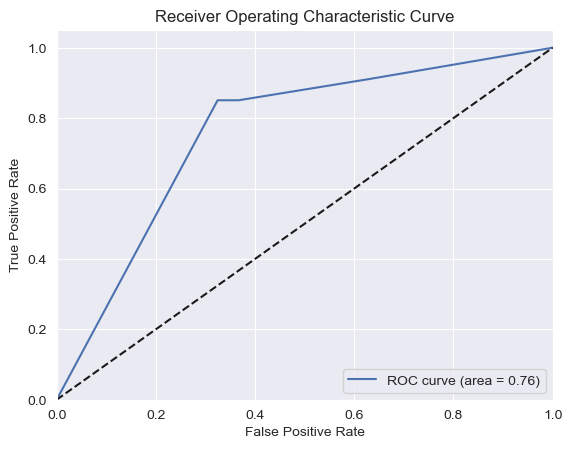

```python
# Get the best parameter

print("Best Params: ", clf_ada_grid.best_params_)
best_clf_ada = clf_ada_grid.best_estimator_

# Predict the tuned model
pred_ada = best_clf_ada.predict(X_test)

print("ROC score on testing data: {:.4f}".format(roc_auc_score(y_test, pred_ada)))



# Print Accuracy Score
print ("Accuracy Score:{:.4f}".format(accuracy_score(y_test,pred_ada)))
print ('')

# Classification report
print("Classification report")
print(classification_report(y_test, pred_ada))
print ('')

# Evaluate the model
evaluate_model_ROC(best_clf_ada, X_test, y_test)
```

> After hyper-tuning, while Gradient Boosting Classifier takes more time for tuning, it shows a better and reasonable ROC score. Although it's very quick of Adaboosting Classifier, it reveals a linear ROC curve which could lead to an extrem result. Nevertheless, these two models will be used for further prediction.

### Prediction on the test data

```python
# Load the test dataset
df_test = pd.read_csv('/Users/johnma/Desktop/Udacity_Data Scientist/Project folder/Project 4_Capstone Project/data/Udacity_MAILOUT_052018_test.csv', sep=';')
```

```python
print ('Show data info of Udacity_MAILOUT_052018_test')
print ('==============================')
print (df_test.info())
```

```
Show data info of Udacity_MAILOUT_052018_test
==============================
<class 'pandas.core.frame.DataFrame'>
RangeIndex: 42833 entries, 0 to 42832
Columns: 366 entries, LNR to ALTERSKATEGORIE_GROB
dtypes: float64(267), int64(93), object(6)
memory usage: 119.6+ MB
None
```

```python
df_test_clean = clean_supervised_dataframe(df_test, attributes_values, col_to_drop_train)
```

```python
df_test_clean.info()
```

```
<class 'pandas.core.frame.DataFrame'>
Int64Index: 30706 entries, 0 to 42832
Columns: 272 entries, LNR to CAMEO_INTL_2015_STATUS
dtypes: float64(272)
memory usage: 64.0 MB
```

```python
df_test_clean.head()
```

|  | LNR | AKT_DAT_KL | ANZ_KINDER | ARBEIT | BALLRAUM | CAMEO_DEUG_2015 | CJT_GESAMTTYP | CJT_KATALOGNUTZER | CJT_TYP_1 | CJT_TYP_2 | CJT_TYP_3 | CJT_TYP_4 | CJT_TYP_5 | CJT_TYP_6 | D19_BANKEN_ANZ_12 | D19_BANKEN_ANZ_24 | D19_BANKEN_DATUM | D19_BANKEN_DIREKT | D19_BANKEN_GROSS | D19_BANKEN_LOKAL | D19_BANKEN_OFFLINE_DATUM | D19_BANKEN_ONLINE_DATUM | D19_BANKEN_ONLINE_QUOTE_12 | D19_BANKEN_REST | D19_BEKLEIDUNG_GEH | D19_BEKLEIDUNG_REST | D19_BILDUNG | D19_BIO_OEKO | D19_BUCH_CD | … |
| --- | --- | --- | --- | --- | --- | --- | --- | --- | --- | --- | --- | --- | --- | --- | --- | --- | --- | --- | --- | --- | --- | --- | --- | --- | --- | --- | --- | --- | --- | --- |
| 0 | 1754.0 | 1.0 | 0.0 | 3.0 | 6.0 | 2.0 | 5.0 | 5.0 | 1.0 | 2.0 | 5.0 | 5.0 | 5.0 | 5.0 | 0.0 | 0.0 | 10.0 | 0.0 | 0.0 | 0.0 | 10.0 | 10.0 | 0.0 | 0.0 | 3.0 | 6.0 | 0.0 | 0.0 | 0.0 | … |
| 1 | 1770.0 | 1.0 | 0.0 | 4.0 | 7.0 | 5.0 | 1.0 | 5.0 | 2.0 | 2.0 | 5.0 | 5.0 | 4.0 | 5.0 | 0.0 | 0.0 | 10.0 | 0.0 | 0.0 | 0.0 | 10.0 | 10.0 | 0.0 | 0.0 | 0.0 | 6.0 | 0.0 | 0.0 | 7.0 | … |
| 2 | 1465.0 | 9.0 | 0.0 | 4.0 | 1.0 | 7.0 | 2.0 | 5.0 | 2.0 | 2.0 | 5.0 | 5.0 | 5.0 | 5.0 | 0.0 | 0.0 | 10.0 | 0.0 | 0.0 | 0.0 | 10.0 | 10.0 | 0.0 | 0.0 | 0.0 | 0.0 | 0.0 | 0.0 | 6.0 | … |
| 4 | 1478.0 | 1.0 | 0.0 | 3.0 | 6.0 | 5.0 | 6.0 | 1.0 | 3.0 | 2.0 | 4.0 | 4.0 | 4.0 | 3.0 | 3.0 | 4.0 | 2.0 | 2.0 | 2.0 | 0.0 | 8.0 | 2.0 | 10.0 | 6.0 | 6.0 | 6.0 | 5.0 | 0.0 | 3.0 | … |
| 5 | 1782.0 | 1.0 | 0.0 | 4.0 | 1.0 | 9.0 | 1.0 | 5.0 | 1.0 | 1.0 | 5.0 | 5.0 | 5.0 | 5.0 | 0.0 | 0.0 | 10.0 | 0.0 | 0.0 | 0.0 | 10.0 | 10.0 | 0.0 | 0.0 | 0.0 | 0.0 | 0.0 | 0.0 | 0.0 | … |

```python
# Copying LNR column and drop it

df_test_LNR = df_test_clean['LNR']

df_test_clean.drop(['LNR'], axis=1, inplace=True)
```

```python
# Scale the data
df_test_scale = pd.DataFrame(scaler.fit_transform(df_test_clean))
df_test_scale.head()
```

|  | 0 | 1 | 2 | 3 | 4 | 5 | 6 | 7 | 8 | 9 | 10 | 11 | 12 | 13 | 14 | 15 | 16 | 17 | 18 | 19 | 20 | 21 | 22 | 23 | 24 | 25 | 26 | 27 | 28 | … |
| --- | --- | --- | --- | --- | --- | --- | --- | --- | --- | --- | --- | --- | --- | --- | --- | --- | --- | --- | --- | --- | --- | --- | --- | --- | --- | --- | --- | --- | --- | --- |
| 0 | -0.273241 | -0.231637 | -0.017305 | 0.775165 | -1.205089 | 1.371586 | 0.903488 | -1.147372 | 0.128762 | 0.644484 | 0.664887 | 0.640650 | 0.645806 | -0.257272 | -0.318676 | 0.461623 | -0.443622 | -0.348625 | -0.154936 | 0.211127 | 0.352292 | -0.219195 | -0.307989 | 0.903296 | 1.410257 | -0.530565 | -0.388717 | -1.104087 | -0.217158 | … |
| 1 | -0.273241 | -0.231637 | 0.938377 | 1.235307 | 0.040693 | -1.274177 | 0.903488 | -0.161443 | 0.128762 | 0.644484 | 0.664887 | -0.360561 | 0.645806 | -0.257272 | -0.318676 | 0.461623 | -0.443622 | -0.348625 | -0.154936 | 0.211127 | 0.352292 | -0.219195 | -0.307989 | -0.487614 | 1.410257 | -0.530565 | -0.388717 | 1.362519 | -0.217158 | … |
| 2 | 4.831033 | -0.231637 | 0.938377 | -1.525545 | 0.871215 | -0.612736 | 0.903488 | -0.161443 | 0.128762 | 0.644484 | 0.664887 | 0.640650 | 0.645806 | -0.257272 | -0.318676 | 0.461623 | -0.443622 | -0.348625 | -0.154936 | 0.211127 | 0.352292 | -0.219195 | -0.307989 | -0.487614 | -0.741249 | -0.530565 | -0.388717 | 1.010147 | -0.217158 | … |
| 3 | -0.273241 | -0.231637 | -0.017305 | 0.775165 | 0.040693 | 2.033027 | -1.760090 | 0.824487 | 0.128762 | -0.389884 | -0.225204 | -0.360561 | -1.297275 | 5.649849 | 5.364647 | -3.919001 | 0.553074 | 0.883662 | -0.154936 | -1.876414 | -4.872286 | 4.642560 | 3.434925 | 2.294206 | 1.410257 | 1.515236 | -0.388717 | -0.046970 | -0.217158 | … |
| 4 | -0.273241 | -0.231637 | 0.938377 | -1.525545 | 1.701736 | -1.274177 | 0.903488 | -1.147372 | -0.907067 | 0.644484 | 0.664887 | 0.640650 | 0.645806 | -0.257272 | -0.318676 | 0.461623 | -0.443622 | -0.348625 | -0.154936 | 0.211127 | 0.352292 | -0.219195 | -0.307989 | -0.487614 | -0.741249 | -0.530565 | -0.388717 | -1.104087 | -0.217158 | … |

```python
# Predict the model -- by GBC
predict_test_gbc = best_clf_gbc.predict_proba(df_test_scale)
print (predict_test_gbc[:10])
print ("")

# Predict the model -- by ADA
predict_test_ada = best_clf_ada.predict_proba(df_test_scale)
print (predict_test_ada[:10])
```

```
[[9.97481534e-01 2.51846611e-03]
 [9.96768402e-01 3.23159810e-03]
 [9.98651534e-01 1.34846587e-03]
 [9.98395946e-01 1.60405413e-03]
 [9.99026545e-01 9.73454616e-04]
 [5.06708447e-02 9.49329155e-01]
 [9.97748447e-01 2.25155313e-03]
 [9.97497012e-01 2.50298844e-03]
 [9.95805148e-01 4.19485162e-03]
 [9.97749857e-01 2.25014302e-03]]

[[0.67617467 0.32382533]
 [0.67617467 0.32382533]
 [0.67617467 0.32382533]
 [0.67617467 0.32382533]
 [0.67617467 0.32382533]
 [0.66088341 0.33911659]
 [0.67617467 0.32382533]
 [0.67617467 0.32382533]
 [0.67617467 0.32382533]
 [0.67617467 0.32382533]]
```

```python
# Generate data -- predicted by GBC

prediction_gbc = pd.DataFrame({'LNR':df_test_LNR.astype(np.int32), 'RESPONSE':predict_test_gbc[:, 1]})
print ("Number unique user ID of RESPONSE over 50%:",len(prediction_gbc[prediction_gbc['RESPONSE']>0.5]))
prediction_gbc.sort_values(by='RESPONSE').head(10)
```

```
Number unique user ID of RESPONSE over 50%: 3596
```

|  | LNR | RESPONSE |
| --- | --- | --- |
| 13208 | 73733 | 0.000113 |
| 3412 | 17878 | 0.000124 |
| 13668 | 81326 | 0.000180 |
| 14451 | 1162 | 0.000190 |
| 1930 | 67661 | 0.000194 |
| 21221 | 75241 | 0.000220 |
| 14514 | 44241 | 0.000226 |
| 32733 | 68230 | 0.000230 |
| 39298 | 75425 | 0.000232 |
| 39734 | 34042 | 0.000237 |

```python
# Generate data -- predicted by ADA

prediction_ada = pd.DataFrame({'LNR':df_test_LNR.astype(np.int32), 'RESPONSE':predict_test_ada[:, 1]})
print ("Number unique user ID of RESPONSE over 50%:",len(prediction_ada[prediction_ada['RESPONSE']>0.5]))
prediction_ada.sort_values(by='RESPONSE').head(10)
```

```
Number unique user ID of RESPONSE over 50%: 0
```

|  | LNR | RESPONSE |
| --- | --- | --- |
| 0 | 1754 | 0.323825 |
| 25100 | 40659 | 0.323825 |
| 25097 | 45477 | 0.323825 |
| 25094 | 44821 | 0.323825 |
| 25091 | 43536 | 0.323825 |
| 25089 | 43530 | 0.323825 |
| 25087 | 42896 | 0.323825 |
| 25086 | 42892 | 0.323825 |
| 25084 | 42573 | 0.323825 |
| 25083 | 42258 | 0.323825 |

### Analysis -- feature importance

```python
feat_importance = best_clf_gbc.feature_importances_

num_feat = 8

indices = np.argsort(feat_importance)[::-1]
columns = X_train.columns.values[indices[:num_feat]]
values = feat_importance[indices][:num_feat]

print(columns)
print(values)
```

```
['D19_SOZIALES' 'VK_DISTANZ' 'VK_DHT4A' 'CAMEO_DEUG_2015'
 'ONLINE_AFFINITAET' 'KBA13_FIAT' 'D19_VERSI_ONLINE_DATUM'
 'KBA13_HALTER_35']
[0.01959406 0.01723751 0.01137307 0.01134201 0.01128955 0.01050101
 0.01001717 0.00831474]
```

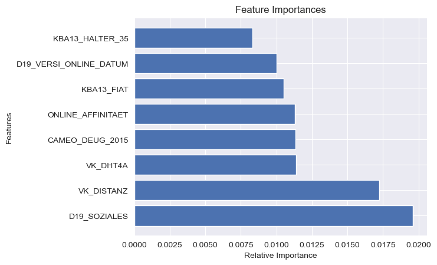

```python
plt.title('Feature Importances')
plt.barh(np.arange(num_feat), values, color=base_color, align='center', label = "Feature Weight")
plt.yticks(np.arange(num_feat), columns)
plt.ylabel('Features')
plt.xlabel('Relative Importance')
plt.show()
```

## Conclusion

Coping with the data was certainly among the biggest challenges in this project. However, it's very interesting to engage in the exercies comply with the problems of real world. Dealing with the huge number of missing values and many different types of features could make a gigantic difference on final performance of the model. Customers and general population are clustered into 5 groups, based on the elbow methods of K-modes. The specific characteristics of these two interested focus groups can be broadly identified as middle class who are consumption-oriented and for those live in the distance to the next urban center for 50-60km, while there are still few variables are not explained in the provided document.  
.

To estimate the feedback of customers, the Gradient Boosting Classifier is proved to be the better performed model although it also takes the most of the time for prediction. I believe that there is still room for improvement. Specifically, the following changes to my approach could be considered to optimize achievement in the project:

- A better method to deal with highly imbalanced target
- Verify different approaches to standardize and scale features. For example, Min-Max-Scaler can be utilized rather than Standard Scaler
- Due to the limitation of my calculator, I have to randomly extract fewer sample from the dataset. The result of elbow methods of K-modes would be different if all samples are applied. Similarly, In order to avoid spending too much time on training, only 80% of samples in supervised learning are selected, which may also lead to the differnt outcome.
- Not all parameters are adopt in hyper-tuning.

The result of the project is far from perfect; nevertheless, I hope the process and result presented can be a good practice for further application in the real world.

```python
#pip freeze > requirements.txt
```